# Stroke Data Analysis

George Melrose

2025-01-09

## Formatting Data

### First look at the data

```r
stroke_data <- read_csv("healthcare-dataset-stroke-data.csv")
```

```r
str(stroke_data)
```

```
## spc_tbl_ [5,110 × 12] (S3: spec_tbl_df/tbl_df/tbl/data.frame)
##  $ id               : num [1:5110] 9046 51676 31112 60182 1665 ...
##  $ gender           : chr [1:5110] "Male" "Female" "Male" "Female" ...
##  $ age              : num [1:5110] 67 61 80 49 79 81 74 69 59 78 ...
##  $ hypertension     : num [1:5110] 0 0 0 0 1 0 1 0 0 0 ...
##  $ heart_disease    : num [1:5110] 1 0 1 0 0 0 1 0 0 0 ...
##  $ ever_married     : chr [1:5110] "Yes" "Yes" "Yes" "Yes" ...
##  $ work_type        : chr [1:5110] "Private" "Self-employed" "Private" "Private" ...
##  $ residence_type   : chr [1:5110] "Urban" "Rural" "Rural" "Urban" ...
##  $ avg_glucose_level: num [1:5110] 229 202 106 171 174 ...
##  $ bmi              : chr [1:5110] "36.6" "N/A" "32.5" "34.4" ...
##  $ smoking_status   : chr [1:5110] "formerly smoked" "never smoked" "never smoked" "smokes" ...
##  $ stroke           : num [1:5110] 1 1 1 1 1 1 1 1 1 1 ...
##  - attr(*, "spec")=
##   .. cols(
##   ..   id = col_double(),
##   ..   gender = col_character(),
##   ..   age = col_double(),
##   ..   hypertension = col_double(),
##   ..   heart_disease = col_double(),
##   ..   ever_married = col_character(),
##   ..   work_type = col_character(),
##   ..   residence_type = col_character(),
##   ..   avg_glucose_level = col_double(),
##   ..   bmi = col_character(),
##   ..   smoking_status = col_character(),
##   ..   stroke = col_double()
##   .. )
##  - attr(*, "problems")=<externalptr>
```

```r
ff_glimpse(stroke_data)
```

```
## $Continuous
##                               label var_type    n missing_n missing_percent
## id                               id    <dbl> 5110         0             0.0
## age                             age    <dbl> 5110         0             0.0
## hypertension           hypertension    <dbl> 5110         0             0.0
## heart_disease         heart_disease    <dbl> 5110         0             0.0
## avg_glucose_level avg_glucose_level    <dbl> 5110         0             0.0
## stroke                       stroke    <dbl> 5110         0             0.0
##                      mean      sd  min quartile_25  median quartile_75     max
## id                36517.8 21161.7 67.0     17741.2 36932.0     54682.0 72940.0
## age                  43.2    22.6  0.1        25.0    45.0        61.0    82.0
## hypertension          0.1     0.3  0.0         0.0     0.0         0.0     1.0
## heart_disease         0.1     0.2  0.0         0.0     0.0         0.0     1.0
## avg_glucose_level   106.1    45.3 55.1        77.2    91.9       114.1   271.7
## stroke                0.0     0.2  0.0         0.0     0.0         0.0     1.0
##
## $Categorical
##                         label var_type    n missing_n missing_percent levels_n
## gender                 gender    <chr> 5110         0             0.0        3
## ever_married     ever_married    <chr> 5110         0             0.0        2
## work_type           work_type    <chr> 5110         0             0.0        5
## residence_type residence_type    <chr> 5110         0             0.0        2
## bmi                       bmi    <chr> 5110         0             0.0      419
## smoking_status smoking_status    <chr> 5110         0             0.0        4
##                levels levels_count levels_percent
## gender              -            -              -
## ever_married        -            -              -
## work_type           -            -              -
## residence_type      -            -              -
## bmi                 -            -              -
## smoking_status      -            -              -
```

```r
#Removing children as lifestyle factors will be far less connected to pediatric stroke - https://www.stroke.org.uk/stroke/childhood/about #

#No.rows with children#
print(paste("The number of rows of the data with children included -", nrow(stroke_data)))
```

```
## [1] "The number of rows of the data with children included - 5110"
```

```r
#Removing children by filtering out all rows with age<18#
children <- stroke_data %>% filter(age < 18)

print(paste("The number of rows of the data that are children (age<18) -", nrow(children)))
```

```
## [1] "The number of rows of the data that are children (age<18) - 856"
```

```r
stroke_data <- stroke_data %>% filter(age >= 18)

print(paste("The number of rows of the data without children included -", nrow(stroke_data)))
```

```
## [1] "The number of rows of the data without children included - 4254"
```

```r
#Creating yes/no (yn) versions of the binary outcome variables#
stroke_data$hypertension_yn <- as.factor(ifelse(stroke_data$hypertension == 1, "Yes", "No"))
stroke_data$heart_disease_yn <- as.factor(ifelse(stroke_data$heart_disease == 1, "Yes", "No"))
stroke_data$stroke_yn <- as.factor(ifelse(stroke_data$stroke == 1, "Yes", "No"))

#re-leveling above yn variables to have "No" as the default and adding ff_label command for cleaner formatting in finalfit plots#

stroke_data <- stroke_data %>% mutate(
  hypertension_yn = relevel(factor(hypertension_yn), ref = "No") %>%
    ff_label("Hypertension (Yes/No)"),

  heart_disease_yn = relevel(factor(heart_disease_yn), ref = "No") %>%
    ff_label("Heart Disease (Yes/No)"),

  stroke_yn = relevel(factor(stroke_yn), ref = "No") %>%
    ff_label("Stroke (Yes/No)")
)
```

```r
set.seed(123)  # For reproducibility

# Simulate follow-up times in days
stroke_data <- stroke_data %>%
  mutate(
    follow_up_time_days = runif(n(), min = 0, max = 1825),  # Time between 0 and 5 years for all
    # Assume the event occurs within the observed time or they are censored
    status = ifelse(stroke == 1, 1, 0)  # 1 = event (stroke), 0 = censored (no stroke)
  )

# Making up a follow up time in years
stroke_data <- stroke_data %>%
  mutate(
    follow_up_time_days = as.numeric(follow_up_time_days),  # Replace with your column name
    follow_up_years = follow_up_time_days / 365         # Convert days to years
  )

# Show sample data with follow-up time in days
head(stroke_data)
```

```
## # A tibble: 6 × 18
##      id gender   age hypertension heart_disease ever_married work_type
##   <dbl> <chr>  <dbl>        <dbl>         <dbl> <chr>        <chr>
## 1  9046 Male      67            0             1 Yes          Private
## 2 51676 Female    61            0             0 Yes          Self-employed
## 3 31112 Male      80            0             1 Yes          Private
## 4 60182 Female    49            0             0 Yes          Private
## 5  1665 Female    79            1             0 Yes          Self-employed
## 6 56669 Male      81            0             0 Yes          Private
## # ℹ 11 more variables: residence_type <chr>, avg_glucose_level <dbl>,
## #   bmi <chr>, smoking_status <chr>, stroke <dbl>, hypertension_yn <fct>,
## #   heart_disease_yn <fct>, stroke_yn <fct>, follow_up_time_days <dbl>,
## #   status <dbl>, follow_up_years <dbl>
```

```r
datatable(stroke_data[1:10, ],options = list(scrollX = TRUE))
```

|  | id | gender | age | hypertension | heart_disease | ever_married | work_type | residence_type | avg_glucose_level | bmi | smoking_status | stroke | hypertension_yn | heart_disease_yn | stroke_yn | follow_up_time_days | status | follow_up_years |
| --- | --- | --- | --- | --- | --- | --- | --- | --- | --- | --- | --- | --- | --- | --- | --- | --- | --- | --- |
| 1 | 9046 | Male | 67 | 0 | 1 | Yes | Private | Urban | 228.69 | 36.6 | formerly smoked | 1 | No | Yes | Yes | 524.828974227421 | 1 | 1.437887600623071 |
| 2 | 51676 | Female | 61 | 0 | 0 | Yes | Self-employed | Rural | 202.21 | N/A | never smoked | 1 | No | No | Yes | 1438.656872184947 | 1 | 3.941525677219033 |
| 3 | 31112 | Male | 80 | 0 | 1 | Yes | Private | Rural | 105.92 | 32.5 | never smoked | 1 | No | Yes | Yes | 746.3828823063523 | 1 | 2.044884609058499 |
| 4 | 60182 | Female | 49 | 0 | 0 | Yes | Private | Urban | 171.23 | 34.4 | smokes | 1 | No | No | Yes | 1611.506762309 | 1 | 4.415087020024657 |
| 5 | 1665 | Female | 79 | 1 | 0 | Yes | Self-employed | Rural | 174.12 | 24 | never smoked | 1 | Yes | No | Yes | 1716.352793836268 | 1 | 4.702336421469226 |
| 6 | 56669 | Male | 81 | 0 | 0 | Yes | Private | Urban | 186.21 | 29 | formerly smoked | 1 | No | No | Yes | 83.1406113866251 | 1 | 0.2277824969496578 |
| 7 | 53882 | Male | 74 | 1 | 1 | Yes | Private | Rural | 70.09 | 27.4 | never smoked | 1 | Yes | Yes | Yes | 963.7925156857818 | 1 | 2.640527440235019 |
| 8 | 10434 | Female | 69 | 0 | 0 | No | Private | Urban | 94.39 | 22.8 | never smoked | 1 | No | No | Yes | 1628.664756019134 | 1 | 4.46209522197023 |
| 9 | 27419 | Female | 59 | 0 | 0 | Yes | Private | Rural | 76.15 | N/A | Unknown | 1 | No | No | Yes | 1006.368901400128 | 1 | 2.757175072329119 |
| 10 | 60491 | Female | 78 | 0 | 0 | Yes | Private | Urban | 58.57 | 24.2 | Unknown | 1 | No | No | Yes | 833.3218919287901 | 1 | 2.283073676517233 |

```r
stroke_data$bmi <- as.numeric(stroke_data$bmi)

stroke_data <- stroke_data %>% mutate(
  # Create age categories
  # Only 2 categories created as 18-35 year olds have only 1 stroke so meaningless
  # to include them separately
  age_category = case_when(
   age <= 60 ~ "≤60",
   age > 60 ~ ">60"
  ) %>% factor(levels = c("≤60", ">60")),

  # Create BMI categories
  bmi_category = case_when(
    bmi < 18.5 ~ "Underweight",
    bmi >= 18.5 & bmi <= 24.9 ~ "Normal weight",
    bmi >= 25 & bmi <= 29.9 ~ "Overweight",
    bmi >= 30 ~ "Obese",
    TRUE ~ NA_character_
  ) %>% factor(levels = c("Underweight", "Normal weight", "Overweight", "Obese"))

)
```

```r
# Recode 'Unknown' to NA in all relevant columns
stroke_data$smoking_status <- factor(stroke_data$smoking_status) # Ensure smoking_status is a factor
stroke_data$smoking_status[stroke_data$smoking_status == "Unknown"] <- NA

# Optionally drop the 'Unknown' level from the factor levels
stroke_data$smoking_status <- droplevels(stroke_data$smoking_status)
```

### Handling Missingness

```r
ff_glimpse(stroke_data)
```

```
## $Continuous
##                                   label var_type    n missing_n missing_percent
## id                                   id    <dbl> 4254         0             0.0
## age                                 age    <dbl> 4254         0             0.0
## hypertension               hypertension    <dbl> 4254         0             0.0
## heart_disease             heart_disease    <dbl> 4254         0             0.0
## avg_glucose_level     avg_glucose_level    <dbl> 4254         0             0.0
## bmi                                 bmi    <dbl> 4073       181             4.3
## stroke                           stroke    <dbl> 4254         0             0.0
## follow_up_time_days follow_up_time_days    <dbl> 4254         0             0.0
## status                           status    <dbl> 4254         0             0.0
## follow_up_years         follow_up_years    <dbl> 4254         0             0.0
##                        mean      sd  min quartile_25  median quartile_75
## id                  36596.6 21177.4 84.0     17887.0 37089.5     54771.0
## age                    50.2    17.8 18.0        36.0    50.5        64.0
## hypertension            0.1     0.3  0.0         0.0     0.0         0.0
## heart_disease           0.1     0.2  0.0         0.0     0.0         0.0
## avg_glucose_level     108.5    47.8 55.1        77.5    92.5       116.1
## bmi                    30.4     7.2 11.3        25.4    29.2        34.2
## stroke                  0.1     0.2  0.0         0.0     0.0         0.0
## follow_up_time_days   911.2   527.8  0.1       449.0   908.5      1365.0
## status                  0.1     0.2  0.0         0.0     0.0         0.0
## follow_up_years         2.5     1.4  0.0         1.2     2.5         3.7
##                         max
## id                  72918.0
## age                    82.0
## hypertension            1.0
## heart_disease           1.0
## avg_glucose_level     271.7
## bmi                    92.0
## stroke                  1.0
## follow_up_time_days  1824.4
## status                  1.0
## follow_up_years         5.0
##
## $Categorical
##                                   label var_type    n missing_n missing_percent
## gender                           gender    <chr> 4254         0             0.0
## ever_married               ever_married    <chr> 4254         0             0.0
## work_type                     work_type    <chr> 4254         0             0.0
```

[output cut: 25 more lines]

```
## heart_disease_yn                                           "No", "Yes", "(Missing)"
## stroke_yn                                                  "No", "Yes", "(Missing)"
## age_category                                              "≤60", ">60", "(Missing)"
## bmi_category     "Underweight", "Normal weight", "Overweight", "Obese", "(Missing)"
##                              levels_count                    levels_percent
## gender                                  -                                 -
## ever_married                            -                                 -
## work_type                               -                                 -
## residence_type                          -                                 -
## smoking_status        860, 1752, 780, 862                    20, 41, 18, 20
## hypertension_yn                 3757, 497                            88, 12
## heart_disease_yn                3979, 275                        93.5,  6.5
## stroke_yn                       4007, 247                        94.2,  5.8
## age_category                   2950, 1304                            69, 31
## bmi_category     38, 865, 1319, 1851, 181  0.89, 20.33, 31.01, 43.51,  4.25
```

```r
# Check how many NAs are in the categorical variable and inspect its unique values
na_categorical_count <- sum(is.na(stroke_data$bmi_category))
cat("Number of NAs in categorical BMI variable:", na_categorical_count, "\n")
```

```
## Number of NAs in categorical BMI variable: 181
```

```r
# View unique BMI category values
unique(stroke_data$bmi_category)
```

```
## [1] Obese         <NA>          Normal weight Overweight    Underweight
## Levels: Underweight Normal weight Overweight Obese
```

There are 181 NAs in the original ‘bmi’ variable. These didn’t show up in the first usage of ff_glimpse() as the variable was a *character* type, so N/A and a numeric value were treated the same. A second usage of ff_glimpse() shows the 181 NAs, which of course are then carried on to the categorical variable when that is made.

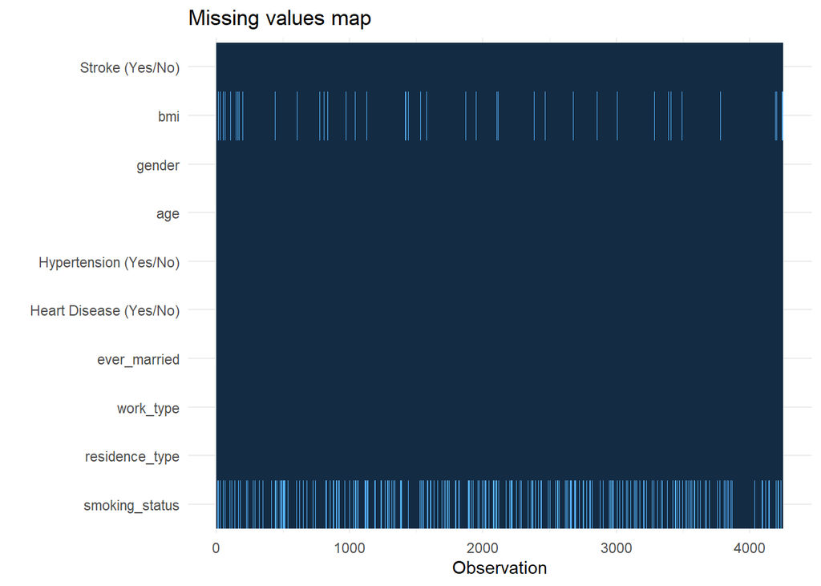

```r
explanatory <- c("bmi","gender","age","hypertension_yn","heart_disease_yn","ever_married",
                 "work_type","residence_type","smoking_status")
dependent <- "stroke_yn"

stroke_data %>%
  missing_plot(dependent, explanatory)
```

There are different types of missingness:

- **MCAR (Missing Completely at Random)** - “Missing data values do not relate to any other data in the dataset and there is no pattern to the actual values of the missing data themselves.”
- **MAR (Missing at Random)** - “This is confusing and would be better named *missing conditionally at random*. Here, missingness in a particular variable has an association with one or more other variables in the dataset. However, the actual values of the missing data are random.”
- **MNAR (Missing not at random)** - “The pattern of missingness is related to other variables in the dataset, but in addition, *the actual values of the missing data are not random*.”

Fo example, in a different dataset, smoking status would be missing in females more likely to smoke but not in males.

“Thus, the complete case female patients have different characteristics to the missing data female patients. For instance, the missing data female patients may be more likely to die after cancer treatment. Looking at our available population, *we therefore under estimate the likelihood of a female dying from cancer treatment*.”

“In deciding whether data is MCAR or MAR, one approach is to explore patterns of missingness between levels of included variables. This is particularly important…for a primary outcome measure / dependent variable.

Take for example “death”. When that outcome is missing it is often for a particular reason. For example, perhaps patients undergoing emergency surgery were less likely to have complete records compared with those undergoing planned surgery. And of course, death is more likely after emergency surgery.”

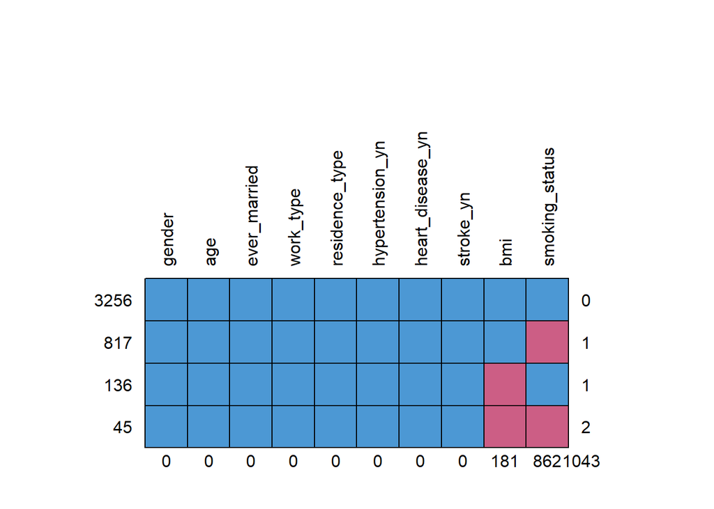

```
##      gender age ever_married work_type residence_type hypertension_yn
## 3256      1   1            1         1              1               1
## 817       1   1            1         1              1               1
## 136       1   1            1         1              1               1
## 45        1   1            1         1              1               1
##           0   0            0         0              0               0
##      heart_disease_yn stroke_yn bmi smoking_status
## 3256                1         1   1              1    0
## 817                 1         1   1              0    1
## 136                 1         1   0              1    1
## 45                  1         1   0              0    2
##                     0         0 181            862 1043
```

```r
stroke_data %>%
  missing_pattern(dependent, explanatory)
```

#### BMI

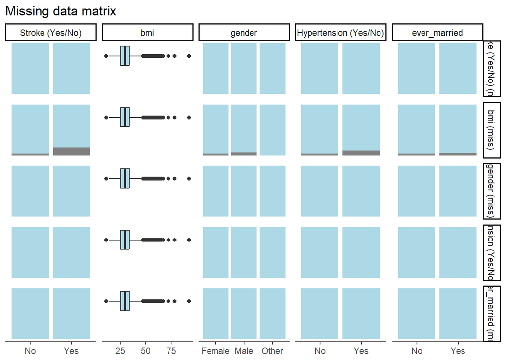

```r
explanatory <- c("bmi","gender","hypertension_yn","ever_married")
dependent <- "stroke_yn"

stroke_data %>%
  missing_pairs(dependent, explanatory, position = "fill")
```

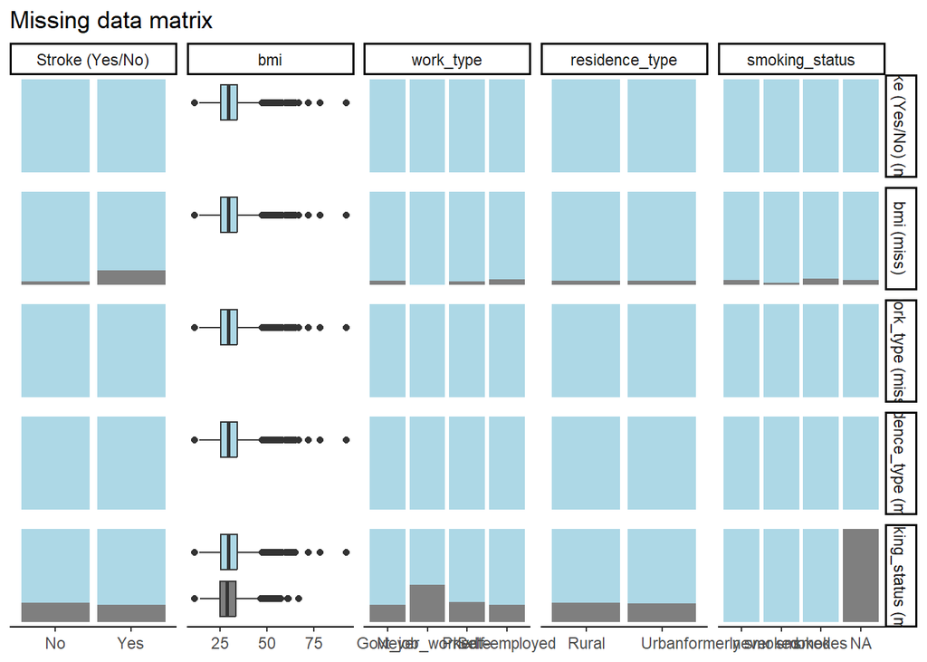

```r
explanatory <- c("bmi","work_type","residence_type","smoking_status")
dependent <- "stroke_yn"

stroke_data %>%
  missing_pairs(dependent, explanatory, position = "fill")
```

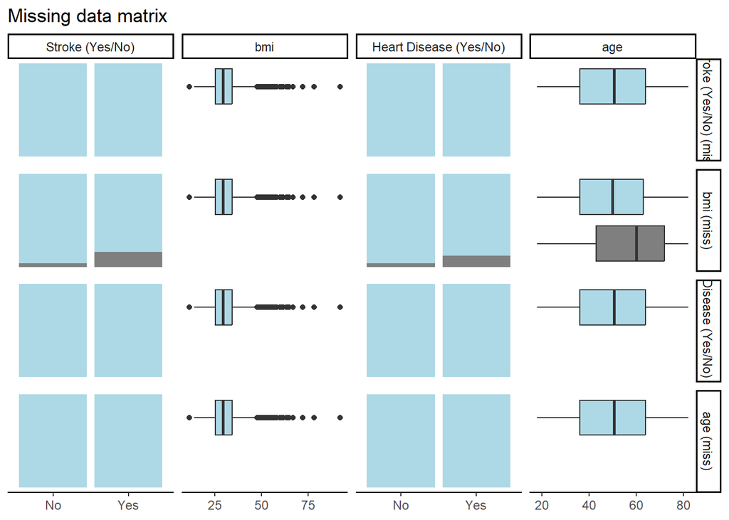

```r
explanatory <- c("bmi","heart_disease_yn","age")
dependent <- "stroke_yn"

stroke_data %>%
  missing_pairs(dependent, explanatory, position = "fill")
```

Looking at the above 3 plots, the following can be observed:

- There is more missingness for the BMI variable in those patients who have stroke than those who do not.
- There is also slightly more missingness in those with hypertension than those patients without it.
- In those patients with heart disease and an average older patients , there is also more BMI missingness.
- Given the above info., we can conclude that the BMI variable missingness is MAR - *missingness in a particular variable that has an association with one or more other variables in the dataset*.

The relevant variables that have an association with missingness in bmi are selected for a single missing pairs plot below.

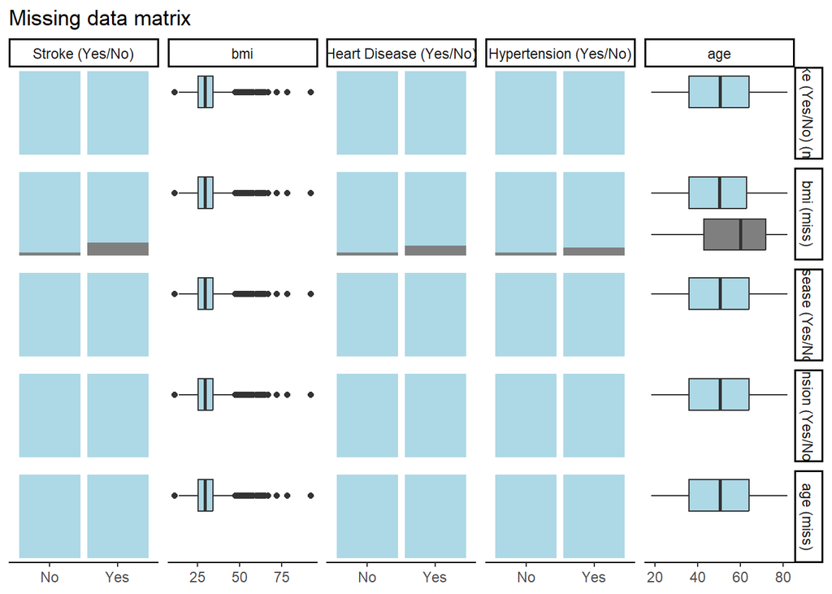

```r
explanatory <- c("bmi","heart_disease_yn","hypertension_yn","age")
dependent <- "stroke_yn"

stroke_data %>%
  missing_pairs(dependent, explanatory, position = "fill")
```

#### Smoking Status

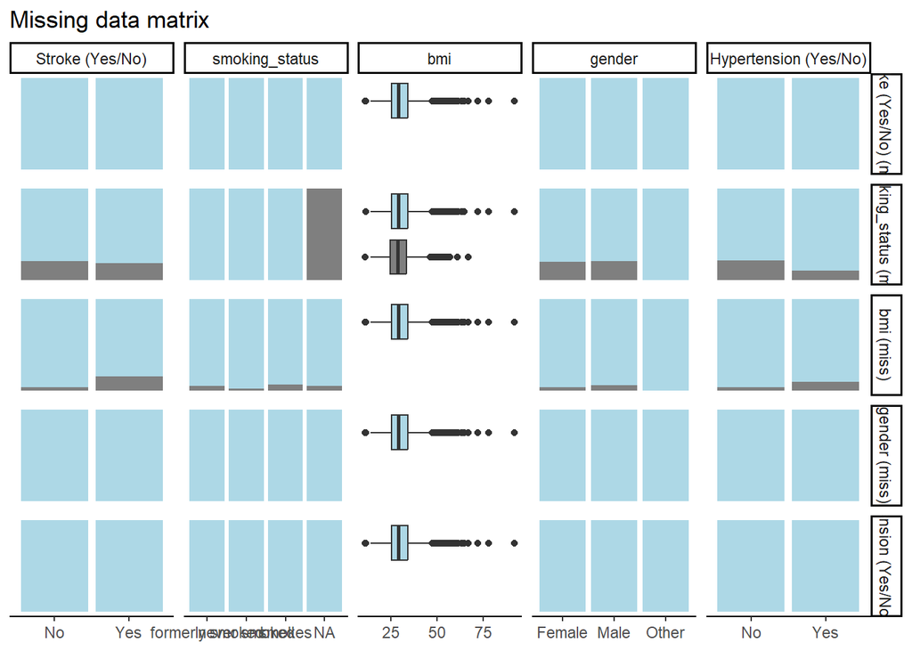

```r
explanatory <- c("smoking_status", "bmi","gender","hypertension_yn")
dependent <- "stroke_yn"

stroke_data %>%
  missing_pairs(dependent, explanatory, position = "fill")
```

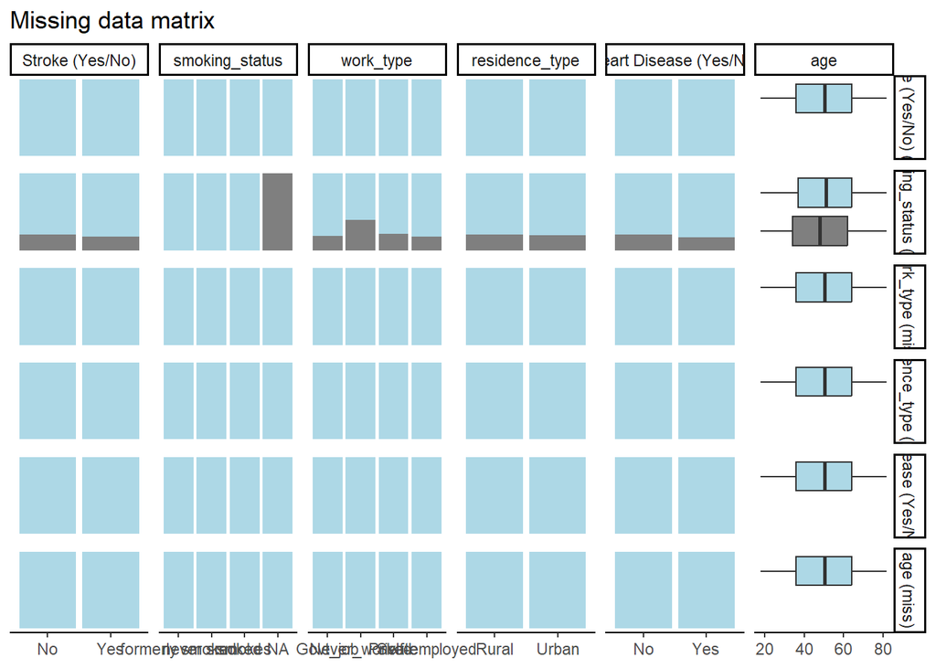

```r
explanatory <- c("smoking_status","work_type","residence_type","heart_disease_yn", "age")
dependent <- "stroke_yn"

stroke_data %>%
  missing_pairs(dependent, explanatory, position = "fill")
```

The relevant variables that have an association with missingness in smoking_status are selected for a single missing pairs plot below.

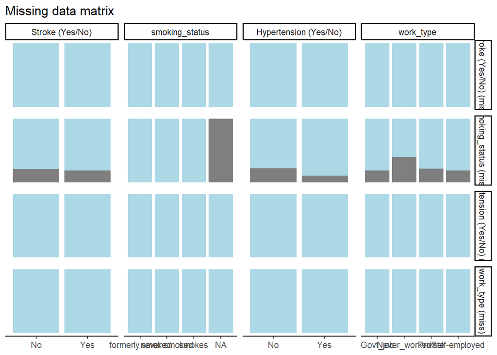

```r
explanatory <- c("smoking_status","hypertension_yn","work_type")
dependent <- "stroke_yn"

stroke_data %>%
  missing_pairs(dependent, explanatory, position = "fill")
```

```r
#gender#
stroke_data$gender <- as.factor(stroke_data$gender)

summary(stroke_data$gender)
```

```
## Female   Male  Other
##   2576   1677      1
```

```r
#ever_married#

stroke_data$ever_married <- as.factor(stroke_data$ever_married)

summary(stroke_data$ever_married)
```

```
##   No  Yes
##  901 3353
```

```r
#work_type#
stroke_data$work_type <- as.factor(stroke_data$work_type)

summary(stroke_data$work_type)
```

```
##      Govt_job  Never_worked       Private Self-employed
##           651             5          2791           807
```

```r
#residence_type#
stroke_data$residence_type <- as.factor(stroke_data$residence_type)

summary(stroke_data$residence_type)
```

```
## Rural Urban
##  2085  2169
```

```r
#smoking_status#
stroke_data$smoking_status <- as.factor(stroke_data$smoking_status)

summary(stroke_data$smoking_status)
```

```
## formerly smoked    never smoked          smokes            NA's
##             860            1752             780             862
```

In the gender and work_type variables there are factor levels with minuscule values - ‘Other’ in gender with 1 and ‘Never_worked’ in work_type with 5. These numbers are extremely small and likely to disturb further analysis so I’ll make them NA so as to not lose the patients but not have the awkward category either.

```r
stroke_data$gender[stroke_data$gender == "Other"] <- NA

stroke_data$work_type[stroke_data$work_type == "Never_worked"] <- NA

stroke_data$gender <- droplevels(stroke_data$gender)

stroke_data$work_type <- droplevels(stroke_data$work_type)


summary(stroke_data$gender)
```

```
## Female   Male   NA's
##   2576   1677      1
```

```r
summary(stroke_data$work_type)
```

```
##      Govt_job       Private Self-employed          NA's
##           651          2791           807             5
```

### MICE on MAR BMI & Smoking Status

Multivariate Imputation by Chained Equations (mice) is “*…the process of filling in missing data using a best-estimate from all the other data that exists.*” (Section 11.8.1 of the HealthyR book)

If missingness in BMI is predicted strongly by stroke outcome (and other observed variables), and the values of the missing data are random, then we can impute (best-guess) the missing BMI values using those variables.

“*Imputation is not usually appropriate for the explanatory variable of interest or the outcome variable, although these can be used to impute other variables. In both cases, the hypothesis is that there is a meaningful association with other variables in the dataset, therefore it doesn’t make sense to use these variables to impute them.*”

The multiple imputation process is as follows:

- **Impute** missing data *m* times, resulting in *m* complete datasets.
- **Diagnose** the quality of the impute values.
- **Analyse** each completed dataset.
- **Pool** the results of the reported analyses.

#### Impute

```r
explanatory <- c("id","bmi","gender","age","hypertension_yn","heart_disease_yn","ever_married",
                 "work_type","residence_type","smoking_status")
dependent <- "stroke_yn"

#Choosing variables to not be imputed but still used by the mice function#
stroke_data %>%
  select(dependent, explanatory) %>%
  missing_predictorMatrix(
    drop_from_imputed = c("gender","age","hypertension_yn","heart_disease_yn","ever_married",
                 "work_type","residence_type","stroke_yn","id"),
    drop_from_imputer = c("gender","ever_married","residence_type","smoking_status",
                          "id")
  ) -> predM
```

```r
fits <- stroke_data %>%
  select(dependent, explanatory) %>%

  # Run imputation with 10 imputed sets
  mice(m = 10, predictorMatrix = predM) %>%

  # Run logistic regression on each imputed set
  with(glm(formula(ff_formula(dependent, explanatory)),
           family="binomial"))
```

#### Diagnose

```r
# Examples of extracting metrics from fits and taking the mean
## AICs
fits %>%
  getfit() %>%
  purrr::map(AIC) %>%
  unlist() %>%
  mean()
```

```
## [1] 1589.044
```

```r
# C-statistic
fits %>%
  getfit() %>%
  purrr::map(~ pROC::roc(.x$y, .x$fitted)$auc) %>%
  unlist() %>%
  mean()
```

```
## [1] 0.8175344
```

#### Analyse

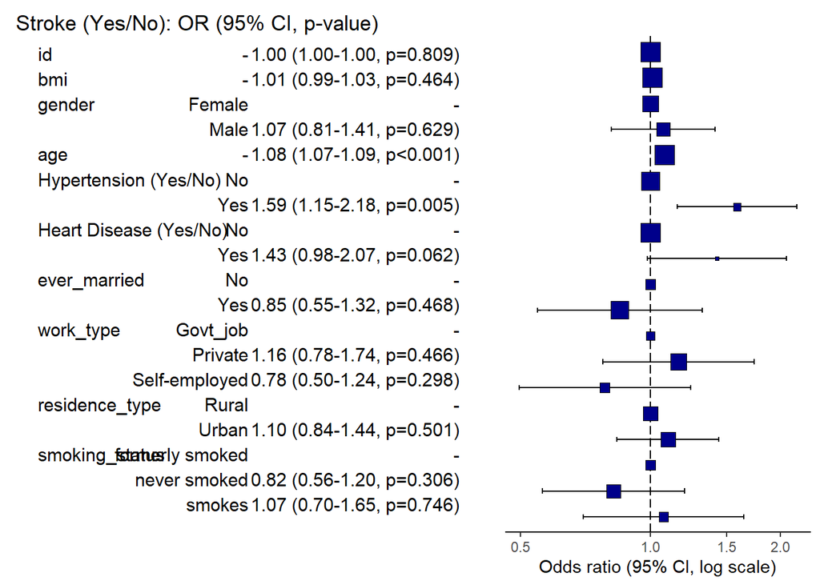

```r
# Pool results
fits_pool <- fits %>%
  pool()

## Can be passed to or_plot
stroke_data %>%
  or_plot(dependent, explanatory, glmfit = fits_pool, table_text_size=4)
```

#### Pool

```r
# Summarise and put in table
fit_imputed <- fits_pool %>%
  fit2df(estimate_name = "OR (multiple imputation)", exp = TRUE)

# Use finalfit merge methods to create and compare results
explanatory <- c("bmi","gender","age","hypertension_yn","heart_disease_yn","ever_married","work_type","residence_type","smoking_status")

table_uni_multi <- stroke_data %>%
  finalfit(dependent, explanatory, keep_fit_id = TRUE)

explanatory = c("gender","age","hypertension_yn","heart_disease_yn","ever_married","work_type","residence_type","smoking_status")

fit_multi_no_bmi <- stroke_data %>%
  glmmulti(dependent, explanatory) %>%
  fit2df(estimate_suffix = " (multivariable without BMI)")

# Combine to final table
table_imputed <-
  table_uni_multi %>%
  ff_merge(fit_multi_no_bmi) %>%
  ff_merge(fit_imputed, last_merge = TRUE)

table_imputed
```

```
##    Dependent: Stroke (Yes/No)                          No         Yes
## 2                         bmi       Mean (SD)  30.4 (7.3)  30.5 (6.3)
## 5                      gender          Female 2437 (94.6)   139 (5.4)
## 6                                        Male 1569 (93.6)   108 (6.4)
## 1                         age       Mean (SD) 49.1 (17.6) 68.2 (11.6)
## 9       Hypertension (Yes/No)              No 3576 (95.2)   181 (4.8)
## 10                                        Yes  431 (86.7)   66 (13.3)
## 7      Heart Disease (Yes/No)              No 3779 (95.0)   200 (5.0)
## 8                                         Yes  228 (82.9)   47 (17.1)
## 3                ever_married              No  874 (97.0)    27 (3.0)
## 4                                         Yes 3133 (93.4)   220 (6.6)
## 17                  work_type        Govt_job  618 (94.9)    33 (5.1)
## 18                                    Private 2642 (94.7)   149 (5.3)
## 19                              Self-employed  742 (91.9)    65 (8.1)
## 12             residence_type           Rural 1972 (94.6)   113 (5.4)
```

[output cut: 45 more lines]

```r
# Summarise and put in table
fit_imputed <- fits_pool %>%
  fit2df(estimate_name = "OR (multiple imputation)", exp = TRUE)

# Use finalfit merge methods to create and compare results
explanatory <- c("bmi","gender","age","hypertension_yn","heart_disease_yn","ever_married","work_type","residence_type","smoking_status")

table_uni_multi <- stroke_data %>%
  finalfit(dependent, explanatory, keep_fit_id = TRUE)

explanatory = c("bmi","gender","age","hypertension_yn","heart_disease_yn","ever_married","work_type","residence_type")

fit_multi_no_smoking_status <- stroke_data %>%
  glmmulti(dependent, explanatory) %>%
  fit2df(estimate_suffix = " (multivariable without Smoking Status)")

# Combine to final table
table_imputed <-
  table_uni_multi %>%
  ff_merge(fit_multi_no_smoking_status) %>%
  ff_merge(fit_imputed, last_merge = TRUE)

table_imputed
```

```
##    Dependent: Stroke (Yes/No)                          No         Yes
## 2                         bmi       Mean (SD)  30.4 (7.3)  30.5 (6.3)
## 5                      gender          Female 2437 (94.6)   139 (5.4)
## 6                                        Male 1569 (93.6)   108 (6.4)
## 1                         age       Mean (SD) 49.1 (17.6) 68.2 (11.6)
## 9       Hypertension (Yes/No)              No 3576 (95.2)   181 (4.8)
## 10                                        Yes  431 (86.7)   66 (13.3)
## 7      Heart Disease (Yes/No)              No 3779 (95.0)   200 (5.0)
## 8                                         Yes  228 (82.9)   47 (17.1)
## 3                ever_married              No  874 (97.0)    27 (3.0)
## 4                                         Yes 3133 (93.4)   220 (6.6)
## 17                  work_type        Govt_job  618 (94.9)    33 (5.1)
## 18                                    Private 2642 (94.7)   149 (5.3)
## 19                              Self-employed  742 (91.9)    65 (8.1)
## 12             residence_type           Rural 1972 (94.6)   113 (5.4)
```

[output cut: 45 more lines]

#### Generating Data & Adding Imputed Values to Original Dataset

```r
explanatory <- c("id","bmi","gender","age","hypertension_yn","heart_disease_yn","ever_married",
                 "work_type","residence_type","smoking_status")
dependent <- "stroke_yn"

stroke_data %>%
  select(dependent, explanatory) %>%
  missing_predictorMatrix(
  drop_from_imputed = c("gender","age","hypertension_yn","heart_disease_yn","ever_married",
                 "work_type","residence_type","stroke_yn","id"),
    drop_from_imputer = c("gender","ever_married","residence_type","smoking_status",
                          "id")
  ) -> predM

fits <- stroke_data %>%
select(dependent, explanatory) %>%
mice(m = 10, predictorMatrix = predM)
completedData <- complete(fits, action = 1)
```

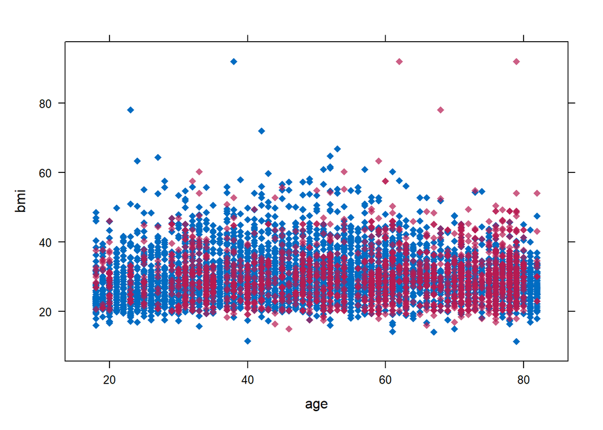

```r
#scatter plot of original and imputed data with the magenta points being the imputed data points and the blue points being the observed values#

xyplot(fits,bmi ~ age,pch=18,cex=1)
```

The above is a scatter plot of original and imputed data with the magenta points being the imputed data points and the blue points being the observed values. The matching shape is a good verification of the imputed values indeed being plausible.

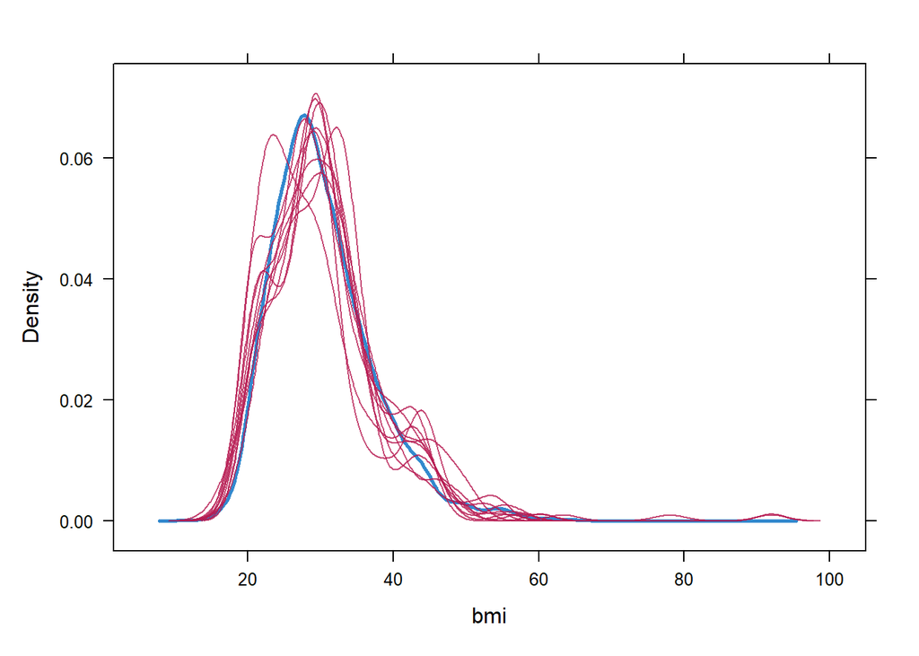

```r
densityplot(fits)
```

The density of the imputed data for each imputed dataset is magenta and the density of the observed data is blue. Again, we expect the distributions to be similar.

```r
ids_wo_bmi <- stroke_data %>% filter(is.na(bmi))

ids_wo_bmi <- ids_wo_bmi$id

imputed_bmi_values <- completedData %>% select(id, bmi)

imputed_bmi_values <- imputed_bmi_values %>% filter(id %in% ids_wo_bmi)
```

```r
stroke_data <- stroke_data %>%
  left_join(imputed_bmi_values, by = "id", suffix = c("", ".new")) %>%
  mutate(bmi = coalesce(bmi, bmi.new)) %>%
  select(-bmi.new)
```

```r
ids_wo_smoking_status <- stroke_data %>% filter(is.na(smoking_status))

ids_wo_smoking_status  <- ids_wo_smoking_status$id

imputed_smoking_status_values <- completedData %>% select(id, smoking_status)

imputed_smoking_status_values <- imputed_smoking_status_values %>% filter(id %in% ids_wo_smoking_status)
```

```r
stroke_data <- stroke_data %>%
  left_join(imputed_smoking_status_values, by = "id", suffix = c("", ".new")) %>%
  mutate(smoking_status = coalesce(smoking_status, smoking_status.new)) %>%
  select(-smoking_status.new)
```

```r
stroke_data <- stroke_data %>% mutate(

  # Create BMI categories
  bmi_category = case_when(
    bmi < 18.5 ~ "Underweight",
    bmi >= 18.5 & bmi <= 24.9 ~ "Normal weight",
    bmi >= 25 & bmi <= 29.9 ~ "Overweight",
    bmi >= 30 ~ "Obese",
    TRUE ~ NA_character_
  ) %>% factor(levels = c("Normal weight", "Underweight", "Overweight", "Obese"))

)
```

```r
ff_glimpse(stroke_data)
```

```
## $Continuous
##                                   label var_type    n missing_n missing_percent
## id                                   id    <dbl> 4254         0             0.0
## age                                 age    <dbl> 4254         0             0.0
## hypertension               hypertension    <dbl> 4254         0             0.0
## heart_disease             heart_disease    <dbl> 4254         0             0.0
## avg_glucose_level     avg_glucose_level    <dbl> 4254         0             0.0
## bmi                                 bmi    <dbl> 4254         0             0.0
## stroke                           stroke    <dbl> 4254         0             0.0
## follow_up_time_days follow_up_time_days    <dbl> 4254         0             0.0
## status                           status    <dbl> 4254         0             0.0
## follow_up_years         follow_up_years    <dbl> 4254         0             0.0
##                        mean      sd  min quartile_25  median quartile_75
## id                  36596.6 21177.4 84.0     17887.0 37089.5     54771.0
## age                    50.2    17.8 18.0        36.0    50.5        64.0
## hypertension            0.1     0.3  0.0         0.0     0.0         0.0
## heart_disease           0.1     0.2  0.0         0.0     0.0         0.0
## avg_glucose_level     108.5    47.8 55.1        77.5    92.5       116.1
## bmi                    30.4     7.3 11.3        25.3    29.1        34.1
## stroke                  0.1     0.2  0.0         0.0     0.0         0.0
## follow_up_time_days   911.2   527.8  0.1       449.0   908.5      1365.0
## status                  0.1     0.2  0.0         0.0     0.0         0.0
## follow_up_years         2.5     1.4  0.0         1.2     2.5         3.7
##                         max
## id                  72918.0
## age                    82.0
## hypertension            1.0
## heart_disease           1.0
## avg_glucose_level     271.7
## bmi                    92.0
## stroke                  1.0
## follow_up_time_days  1824.4
## status                  1.0
## follow_up_years         5.0
##
## $Categorical
##                                   label var_type    n missing_n missing_percent
## gender                           gender    <fct> 4253         1             0.0
## ever_married               ever_married    <fct> 4254         0             0.0
## work_type                     work_type    <fct> 4249         5             0.1
```

[output cut: 25 more lines]

```
## heart_disease_yn                                           "No", "Yes", "(Missing)"
## stroke_yn                                                  "No", "Yes", "(Missing)"
## age_category                                              "≤60", ">60", "(Missing)"
## bmi_category     "Normal weight", "Underweight", "Overweight", "Obese", "(Missing)"
##                         levels_count             levels_percent
## gender                 2576, 1677, 1     60.555, 39.422,  0.024
## ever_married               901, 3353                     21, 79
## work_type          651, 2791, 807, 5 15.30, 65.61, 18.97,  0.12
## residence_type            2085, 2169                     49, 51
## smoking_status       1059, 2224, 971                 25, 52, 23
## hypertension_yn            3757, 497                     88, 12
## heart_disease_yn           3979, 275                 93.5,  6.5
## stroke_yn                  4007, 247                 94.2,  5.8
## age_category              2950, 1304                     69, 31
## bmi_category     935, 38, 1364, 1917 21.98,  0.89, 32.06, 45.06
```

### Removing Blood Glucose Variable

The average glucose level variable can be considered redundant or less informative for exploratory data analysis (EDA) without additional context about when the readings were taken.

Glucose levels can fluctuate significantly based on factors such as fasting status, recent meals, and time of day. For example, a reading taken shortly after eating will typically be higher than a fasting reading -

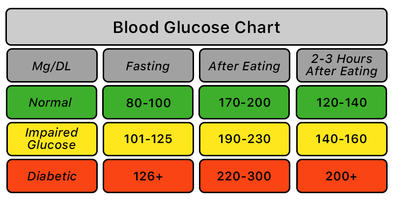

Blood Glucose Chart from ‘Lark Health’

```r
knitr::include_graphics("BloodGlucoseChart.jpeg")
```

Without knowing the conditions under which the glucose levels were measured, it becomes difficult to draw meaningful conclusions or identify trends during EDA. A reading labeled as “normal” may not actually reflect the patient’s metabolic health.

```r
stroke_data <- stroke_data %>% select(-avg_glucose_level)

str(stroke_data)
```

```
## tibble [4,254 × 19] (S3: tbl_df/tbl/data.frame)
##  $ id                 : num [1:4254] 9046 51676 31112 60182 1665 ...
##  $ gender             : Factor w/ 2 levels "Female","Male": 2 1 2 1 1 2 2 1 1 1 ...
##  $ age                : num [1:4254] 67 61 80 49 79 81 74 69 59 78 ...
##  $ hypertension       : num [1:4254] 0 0 0 0 1 0 1 0 0 0 ...
##  $ heart_disease      : num [1:4254] 1 0 1 0 0 0 1 0 0 0 ...
##  $ ever_married       : Factor w/ 2 levels "No","Yes": 2 2 2 2 2 2 2 1 2 2 ...
##  $ work_type          : Factor w/ 3 levels "Govt_job","Private",..: 2 3 2 2 3 2 2 2 2 2 ...
##  $ residence_type     : Factor w/ 2 levels "Rural","Urban": 2 1 1 2 1 2 1 2 1 2 ...
##  $ bmi                : num [1:4254] 36.6 29.9 32.5 34.4 24 29 27.4 22.8 23.7 24.2 ...
##  $ smoking_status     : Factor w/ 3 levels "formerly smoked",..: 1 2 2 3 2 1 2 2 2 3 ...
##  $ stroke             : num [1:4254] 1 1 1 1 1 1 1 1 1 1 ...
##  $ hypertension_yn    : Factor w/ 2 levels "No","Yes": 1 1 1 1 2 1 2 1 1 1 ...
##   ..- attr(*, "label")= chr "Hypertension (Yes/No)"
##  $ heart_disease_yn   : Factor w/ 2 levels "No","Yes": 2 1 2 1 1 1 2 1 1 1 ...
##   ..- attr(*, "label")= chr "Heart Disease (Yes/No)"
##  $ stroke_yn          : Factor w/ 2 levels "No","Yes": 2 2 2 2 2 2 2 2 2 2 ...
##   ..- attr(*, "label")= chr "Stroke (Yes/No)"
##  $ follow_up_time_days: num [1:4254] 525 1439 746 1612 1716 ...
##  $ status             : num [1:4254] 1 1 1 1 1 1 1 1 1 1 ...
##  $ follow_up_years    : num [1:4254] 1.44 3.94 2.04 4.42 4.7 ...
##  $ age_category       : Factor w/ 2 levels "≤60",">60": 2 2 2 1 2 2 2 2 1 2 ...
##  $ bmi_category       : Factor w/ 4 levels "Normal weight",..: 4 3 4 4 1 3 3 1 1 1 ...
```

```r
datatable(stroke_data[1:10, ],options = list(scrollX = TRUE))
```

|  | id | gender | age | hypertension | heart_disease | ever_married | work_type | residence_type | bmi | smoking_status | stroke | hypertension_yn | heart_disease_yn | stroke_yn | follow_up_time_days | status | follow_up_years | age_category | bmi_category |
| --- | --- | --- | --- | --- | --- | --- | --- | --- | --- | --- | --- | --- | --- | --- | --- | --- | --- | --- | --- |
| 1 | 9046 | Male | 67 | 0 | 1 | Yes | Private | Urban | 36.6 | formerly smoked | 1 | No | Yes | Yes | 524.828974227421 | 1 | 1.437887600623071 | &gt;60 | Obese |
| 2 | 51676 | Female | 61 | 0 | 0 | Yes | Self-employed | Rural | 29.9 | never smoked | 1 | No | No | Yes | 1438.656872184947 | 1 | 3.941525677219033 | &gt;60 | Overweight |
| 3 | 31112 | Male | 80 | 0 | 1 | Yes | Private | Rural | 32.5 | never smoked | 1 | No | Yes | Yes | 746.3828823063523 | 1 | 2.044884609058499 | &gt;60 | Obese |
| 4 | 60182 | Female | 49 | 0 | 0 | Yes | Private | Urban | 34.4 | smokes | 1 | No | No | Yes | 1611.506762309 | 1 | 4.415087020024657 | ≤60 | Obese |
| 5 | 1665 | Female | 79 | 1 | 0 | Yes | Self-employed | Rural | 24 | never smoked | 1 | Yes | No | Yes | 1716.352793836268 | 1 | 4.702336421469226 | &gt;60 | Normal weight |
| 6 | 56669 | Male | 81 | 0 | 0 | Yes | Private | Urban | 29 | formerly smoked | 1 | No | No | Yes | 83.1406113866251 | 1 | 0.2277824969496578 | &gt;60 | Overweight |
| 7 | 53882 | Male | 74 | 1 | 1 | Yes | Private | Rural | 27.4 | never smoked | 1 | Yes | Yes | Yes | 963.7925156857818 | 1 | 2.640527440235019 | &gt;60 | Overweight |
| 8 | 10434 | Female | 69 | 0 | 0 | No | Private | Urban | 22.8 | never smoked | 1 | No | No | Yes | 1628.664756019134 | 1 | 4.46209522197023 | &gt;60 | Normal weight |
| 9 | 27419 | Female | 59 | 0 | 0 | Yes | Private | Rural | 23.7 | never smoked | 1 | No | No | Yes | 1006.368901400128 | 1 | 2.757175072329119 | ≤60 | Normal weight |
| 10 | 60491 | Female | 78 | 0 | 0 | Yes | Private | Urban | 24.2 | smokes | 1 | No | No | Yes | 833.3218919287901 | 1 | 2.283073676517233 | &gt;60 | Normal weight |

## Exploratory Data Analysis - Summary Statistics

```
## [1] "Private"       "Govt_job"      "Self-employed"
```

```
## [1] "never smoked"    "formerly smoked" "smokes"
```

```
## [1] "Urban" "Rural"
```

### Age

```r
#dropping children from age category#

stroke_data$age_category <- droplevels(stroke_data$age_category)

summary(stroke_data$age_category)
```

```
##  ≤60  >60
## 2950 1304
```

Summary statistics for age -

```r
summary(stroke_data$age)
```

```
##    Min. 1st Qu.  Median    Mean 3rd Qu.    Max.
##    18.0    36.0    50.5    50.2    64.0    82.0
```

- From the summary statistics we see that the mean and median are 50.2 years and 50.5 years respectively. This is an indication of the age variable being normally distributed.
- The minimum age is 18 as per the earlier filtering removing all children. The maximum age of a patient is 82.

```r
age_counts <- stroke_data %>%
  group_by(age_category) %>%
  summarise(patient_count = n()) %>%
  mutate(percentage = (patient_count / sum(patient_count)) * 100,
        percentage = signif(percentage, 3)) %>%
  arrange(age_category)

age_counts_table <- age_counts %>% rename("Percentage (%)" = percentage) %>% rename(
"No.Patients" = patient_count) %>% rename("Age Category" = age_category)

flextable(age_counts_table)
```

| Age Category | No.Patients | Percentage (%) |
| --- | --- | --- |
| ≤60 | 2,950 | 69.3 |
| >60 | 1,304 | 30.7 |

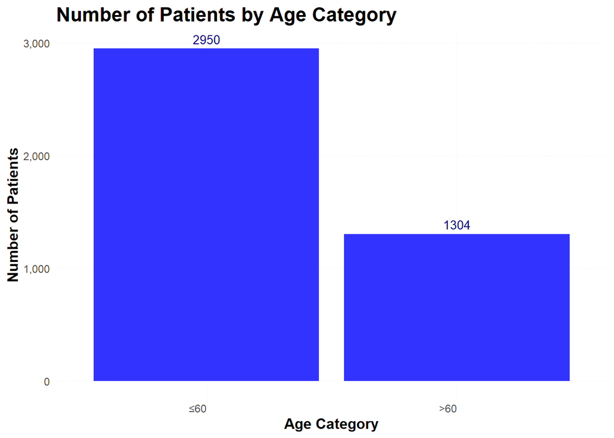

```r
ggplot(age_counts, aes(x = age_category, y = patient_count)) +
  geom_col(fill = "blue", alpha = 0.8) +
  geom_text(aes(label = patient_count), vjust = -0.5, size = 3.5, color = "darkblue") +
  scale_y_continuous(labels = comma) +
  labs(title = "Number of Patients by Age Category",
       x = "Age Category",
       y = "Number of Patients") +
  theme_minimal() +
  theme(
    plot.title = element_text(size = 16, face = "bold"),
    plot.subtitle = element_text(size = 12),
    axis.title.x = element_text(size = 12, face = "bold"),
    axis.title.y = element_text(size = 12, face = "bold"),
    axis.text.x = element_text(hjust = 1),
    panel.grid.major = element_line(size = 0.1, linetype = 'dotted'),
    panel.grid.minor = element_blank()
  )
```

```r
age_counts_w_stroke <- stroke_data %>%
  group_by(age_category,stroke_yn) %>%
  summarise(patient_count = n()) %>%
  mutate(percentage = (patient_count / sum(patient_count)) * 100,
                 percentage = signif(percentage, 3)) %>%
  arrange(age_category)

age_counts_w_stroke_table <- age_counts_w_stroke %>% rename("Percentage (%)" = percentage) %>% rename(
"No.Patients" = patient_count) %>% rename("Age Category" = age_category) %>% rename("Stroke (Yes/No)" = stroke_yn)

flextable(age_counts_w_stroke_table)
```

| Age Category | Stroke (Yes/No) | No.Patients | Percentage (%) |
| --- | --- | --- | --- |
| ≤60 | No | 2,880 | 97.60 |
| ≤60 | Yes | 70 | 2.37 |
| >60 | No | 1,127 | 86.40 |
| >60 | Yes | 177 | 13.60 |

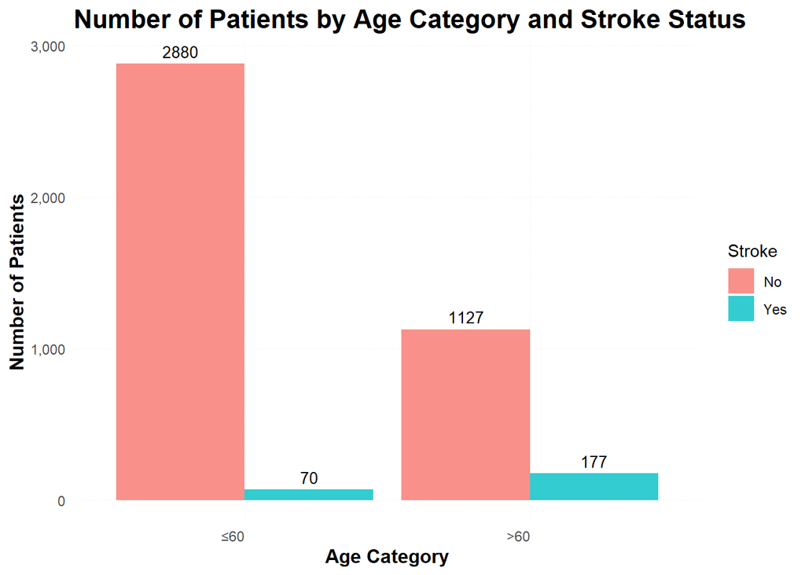

```r
ggplot(age_counts_w_stroke, aes(x = age_category, y = patient_count, fill = stroke_yn)) +
  geom_col(position = "dodge", alpha = 0.8) +
  geom_text(aes(label = patient_count),
            position = position_dodge(width = 0.9),
            vjust = -0.5, size = 3.5) +
  scale_y_continuous(labels = scales::comma) +
  labs(title = "Number of Patients by Age Category and Stroke Status",
       x = "Age Category",
       y = "Number of Patients",
       fill = "Stroke") +
  theme_minimal() +
  theme(
    plot.title = element_text(size = 16, face = "bold"),
    plot.subtitle = element_text(size = 12),
    axis.title.x = element_text(size = 12, face = "bold"),
    axis.title.y = element_text(size = 12, face = "bold"),
    axis.text.x = element_text(hjust = 1),
    panel.grid.major = element_line(size = 0.1, linetype = 'dotted'),
    panel.grid.minor = element_blank()
  )
```

### BMI

Summary statistics for BMI -

```r
#summary statistics for bmi#

summary(stroke_data$bmi)
```

```
##    Min. 1st Qu.  Median    Mean 3rd Qu.    Max.
##   11.30   25.30   29.10   30.38   34.10   92.00
```

```r
bmi_counts <- stroke_data %>%
  group_by(bmi_category) %>%
  summarise(patient_count = n()) %>%
  mutate(percentage = (patient_count / sum(patient_count)) * 100,
        percentage = signif(percentage, 3)) %>%
  arrange(bmi_category)

bmi_counts_table <- bmi_counts %>% rename("Percentage (%)" = percentage) %>% rename(
"No.Patients" = patient_count) %>% rename("BMI Category" = bmi_category)

flextable(bmi_counts_table)
```

| BMI Category | No.Patients | Percentage (%) |
| --- | --- | --- |
| Normal weight | 935 | 22.000 |
| Underweight | 38 | 0.893 |
| Overweight | 1,364 | 32.100 |
| Obese | 1,917 | 45.100 |

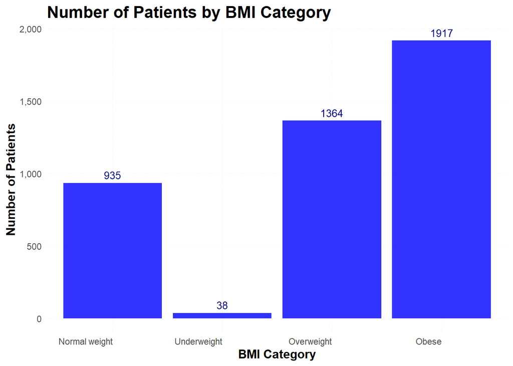

```r
#Code to remove NAs from bmi_counts#

bmi_counts <- bmi_counts %>% filter(!is.na(bmi_category))


ggplot(bmi_counts, aes(x = bmi_category, y = patient_count)) +
  geom_col(fill = "blue", alpha = 0.8) +
  geom_text(aes(label = patient_count), vjust = -0.5, size = 3.5, color = "darkblue") +
  scale_y_continuous(labels = comma) +
  labs(title = "Number of Patients by BMI Category",
       x = "BMI Category",
       y = "Number of Patients") +
  theme_minimal() +
  theme(
    plot.title = element_text(size = 16, face = "bold"),
    plot.subtitle = element_text(size = 12),
    axis.title.x = element_text(size = 12, face = "bold"),
    axis.title.y = element_text(size = 12, face = "bold"),
    axis.text.x = element_text(hjust = 1),
    panel.grid.major = element_line(size = 0.1, linetype = 'dotted'),
    panel.grid.minor = element_blank()
  )
```

The distribution of patients is left skewed towards the ‘Overweight’ and ‘Obese’ categories.

```r
bmi_counts_w_stroke <- stroke_data %>%
  group_by(bmi_category,stroke_yn) %>%
  summarise(patient_count = n()) %>%
  mutate(percentage = (patient_count / sum(patient_count)) * 100,
                 percentage = signif(percentage, 3)) %>%
  arrange(bmi_category)

bmi_counts_w_stroke_table <- bmi_counts_w_stroke %>% rename("Percentage (%)" = percentage) %>% rename(
"No.Patients" = patient_count) %>% rename("BMI Category" = bmi_category) %>% rename("Stroke (Yes/No)" = stroke_yn)

flextable(bmi_counts_w_stroke_table)
```

| BMI Category | Stroke (Yes/No) | No.Patients | Percentage (%) |
| --- | --- | --- | --- |
| Normal weight | No | 884 | 94.50 |
| Normal weight | Yes | 51 | 5.45 |
| Underweight | No | 37 | 97.40 |
| Underweight | Yes | 1 | 2.63 |
| Overweight | No | 1,277 | 93.60 |
| Overweight | Yes | 87 | 6.38 |
| Obese | No | 1,809 | 94.40 |
| Obese | Yes | 108 | 5.63 |

The above summary table shows the percentage of patients having a stroke is higher in the ‘Overweight’ and ‘Obese’ BMI categories than in the ‘Normal Weight’ and ‘Underweight’ categories.

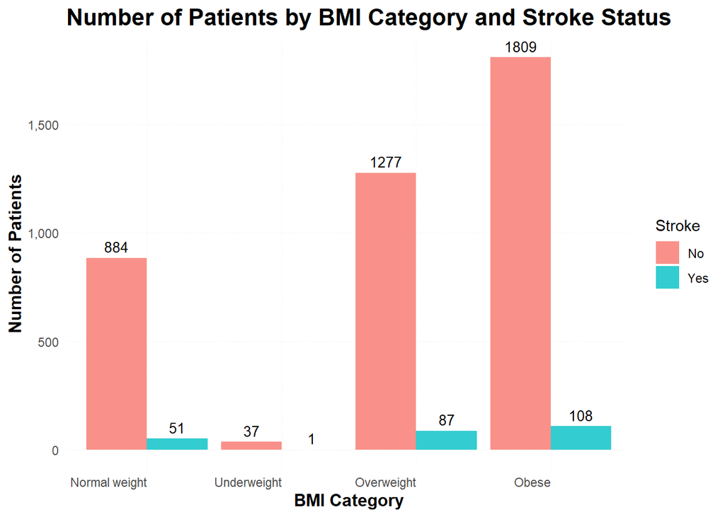

```r
bmi_counts_w_stroke <- bmi_counts_w_stroke %>% filter(!is.na(bmi_category))

ggplot(bmi_counts_w_stroke, aes(x = bmi_category, y = patient_count, fill = stroke_yn)) +
  geom_col(position = "dodge", alpha = 0.8) +
  geom_text(aes(label = patient_count),
            position = position_dodge(width = 0.9),
            vjust = -0.5, size = 3.5) +
  scale_y_continuous(labels = scales::comma) +
  labs(title = "Number of Patients by BMI Category and Stroke Status",
       x = "BMI Category",
       y = "Number of Patients",
       fill = "Stroke") +
  theme_minimal() +
  theme(
    plot.title = element_text(size = 16, face = "bold"),
    plot.subtitle = element_text(size = 12),
    axis.title.x = element_text(size = 12, face = "bold"),
    axis.title.y = element_text(size = 12, face = "bold"),
    axis.text.x = element_text(hjust = 1),
    panel.grid.major = element_line(size = 0.1, linetype = 'dotted'),
    panel.grid.minor = element_blank()
  )
```

There is a higher rate of stroke associated with the ‘Overweight’ and ‘Obese’ BMI categories but perhaps not a significant level.

### Gender

```r
gender_counts <- stroke_data %>%
  group_by(gender) %>%
  summarise(patient_count = n()) %>%
  mutate(percentage = (patient_count / sum(patient_count)) * 100,
        percentage = signif(percentage, 3)) %>%
  arrange(gender)

gender_counts_table <- gender_counts %>% rename("Percentage (%)" = percentage) %>% rename(
"No.Patients" = patient_count) %>% rename("Gender" = gender)

flextable(gender_counts_table)
```

| Gender | No.Patients | Percentage (%) |
| --- | --- | --- |
| Female | 2,576 | 60.6000 |
| Male | 1,677 | 39.4000 |
|  | 1 | 0.0235 |

The cohort is majority female at 60.6% and 39.4% male. One patient is marked as ‘other’. It is unclear what this means - an input mistake, transgender? To not disturb any other modelling, this patient is removed.

```r
stroke_data <- stroke_data %>% filter(gender == "Male" | gender == "Female")
```

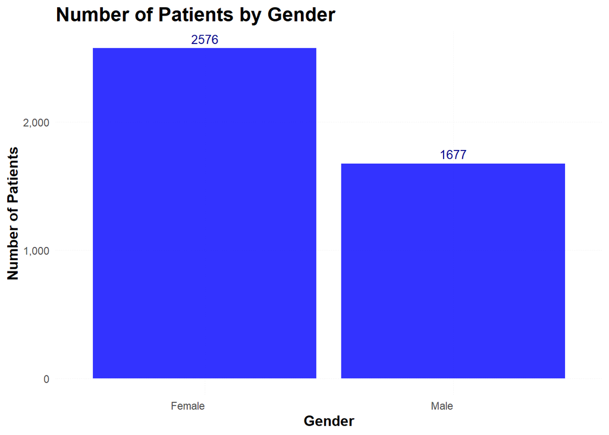

```r
#redoing gender counts to reflect removed 'other' patient'
gender_counts <- stroke_data %>%
  group_by(gender) %>%
  summarise(patient_count = n()) %>%
  mutate(percentage = (patient_count / sum(patient_count)) * 100,
        percentage = signif(percentage, 3)) %>%
  arrange(gender)

ggplot(gender_counts, aes(x = gender, y = patient_count)) +
  geom_col(fill = "blue", alpha = 0.8) +
  geom_text(aes(label = patient_count), vjust = -0.5, size = 3.5, color = "darkblue") +
  scale_y_continuous(labels = comma) +
  labs(title = "Number of Patients by Gender",
       x = "Gender",
       y = "Number of Patients") +
  theme_minimal() +
  theme(
    plot.title = element_text(size = 16, face = "bold"),
    plot.subtitle = element_text(size = 12),
    axis.title.x = element_text(size = 12, face = "bold"),
    axis.title.y = element_text(size = 12, face = "bold"),
    axis.text.x = element_text(hjust = 1),
    panel.grid.major = element_line(size = 0.1, linetype = 'dotted'),
    panel.grid.minor = element_blank()
  )
```

```r
gender_counts_w_stroke <- stroke_data %>%
  group_by(gender,stroke_yn) %>%
  summarise(patient_count = n()) %>%
  mutate(percentage = (patient_count / sum(patient_count)) * 100,
                 percentage = signif(percentage, 3)) %>%
  arrange(gender)

gender_counts_w_stroke_table <- gender_counts_w_stroke %>% rename("Percentage (%)" = percentage) %>% rename(
"No.Patients" = patient_count) %>% rename("Gender" = gender) %>% rename("Stroke (Yes/No)" = stroke_yn)

flextable(gender_counts_w_stroke_table)
```

| Gender | Stroke (Yes/No) | No.Patients | Percentage (%) |
| --- | --- | --- | --- |
| Female | No | 2,437 | 94.60 |
| Female | Yes | 139 | 5.40 |
| Male | No | 1,569 | 93.60 |
| Male | Yes | 108 | 6.44 |

Interestingly, whilst there are many more female than male patients, the rate of stroke between the 2 genders stays consistent. 5.4% (139) of females experienced stroke and 6.44% (108) of males experienced stroke.

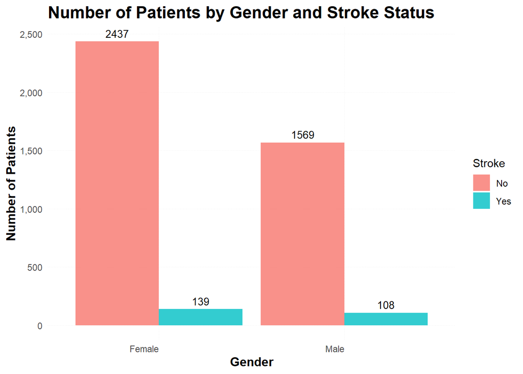

```r
ggplot(gender_counts_w_stroke, aes(x = gender, y = patient_count, fill = stroke_yn)) +
  geom_col(position = "dodge", alpha = 0.8) +
  geom_text(aes(label = patient_count),
            position = position_dodge(width = 0.9),
            vjust = -0.5, size = 3.5) +
  scale_y_continuous(labels = scales::comma) +
  labs(title = "Number of Patients by Gender and Stroke Status",
       x = "Gender",
       y = "Number of Patients",
       fill = "Stroke") +
  theme_minimal() +
  theme(
    plot.title = element_text(size = 16, face = "bold"),
    plot.subtitle = element_text(size = 12),
    axis.title.x = element_text(size = 12, face = "bold"),
    axis.title.y = element_text(size = 12, face = "bold"),
    axis.text.x = element_text(hjust = 1),
    panel.grid.major = element_line(size = 0.1, linetype = 'dotted'),
    panel.grid.minor = element_blank()
  )
```

### Marriage

```r
ever_married_counts <- stroke_data %>%
  group_by(ever_married) %>%
  summarise(patient_count = n()) %>%
  mutate(percentage = (patient_count / sum(patient_count)) * 100,
        percentage = signif(percentage, 3)) %>%
  arrange(ever_married)

ever_married_counts_table <- ever_married_counts %>% rename("Percentage (%)" = percentage) %>% rename(
"No.Patients" = patient_count) %>% rename("Marriage?" = ever_married)

flextable(ever_married_counts_table)
```

| Marriage? | No.Patients | Percentage (%) |
| --- | --- | --- |
| No | 900 | 21.2 |
| Yes | 3,353 | 78.8 |

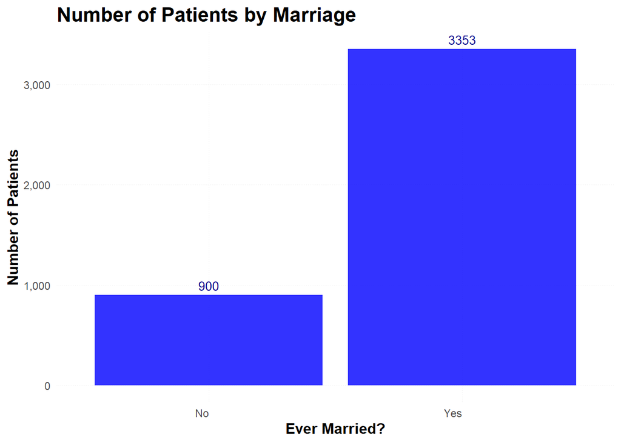

```r
ggplot(ever_married_counts, aes(x = ever_married, y = patient_count)) +
  geom_col(fill = "blue", alpha = 0.8) +
  geom_text(aes(label = patient_count), vjust = -0.5, size = 3.5, color = "darkblue") +
  scale_y_continuous(labels = comma) +
  labs(title = "Number of Patients by Marriage",
       x = "Ever Married?",
       y = "Number of Patients") +
  theme_minimal() +
  theme(
    plot.title = element_text(size = 16, face = "bold"),
    plot.subtitle = element_text(size = 12),
    axis.title.x = element_text(size = 12, face = "bold"),
    axis.title.y = element_text(size = 12, face = "bold"),
    axis.text.x = element_text(hjust = 1),
    panel.grid.major = element_line(size = 0.1, linetype = 'dotted'),
    panel.grid.minor = element_blank()
  )
```

```r
ever_married_counts_w_stroke <- stroke_data %>%
  group_by(ever_married,stroke_yn) %>%
  summarise(patient_count = n()) %>%
  mutate(percentage = (patient_count / sum(patient_count)) * 100,
                 percentage = signif(percentage, 3)) %>%
  arrange(ever_married)

ever_married_counts_w_stroke_table <- ever_married_counts_w_stroke %>% rename("Percentage (%)" = percentage) %>% rename("No.Patients" = patient_count) %>% rename("Ever Married?" = ever_married) %>% rename("Stroke (Yes/No)" = stroke_yn)

flextable(ever_married_counts_w_stroke_table)
```

| Ever Married? | Stroke (Yes/No) | No.Patients | Percentage (%) |
| --- | --- | --- | --- |
| No | No | 873 | 97.00 |
| No | Yes | 27 | 3.00 |
| Yes | No | 3,133 | 93.40 |
| Yes | Yes | 220 | 6.56 |

The above table shows that the proportion of those patients experiencing stroke who had ever married (6.56%) was more than twice as much as the proportion of patients experiencing stroke who had never married (3%).

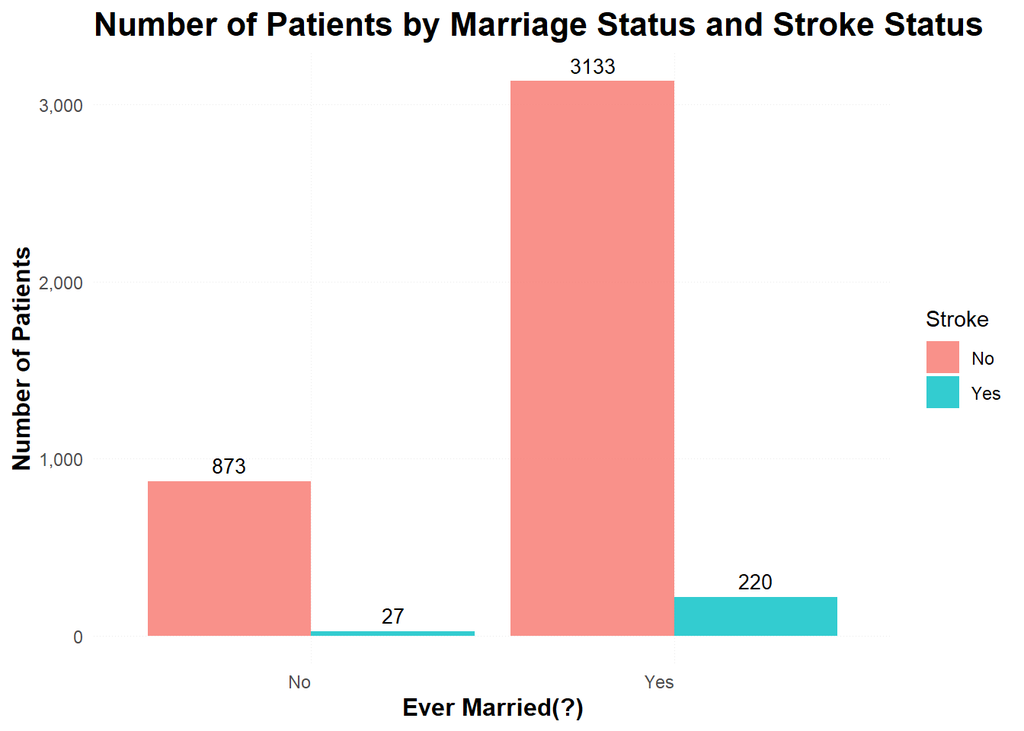

```r
ggplot(ever_married_counts_w_stroke, aes(x = ever_married, y = patient_count, fill = stroke_yn)) +
  geom_col(position = "dodge", alpha = 0.8) +
  geom_text(aes(label = patient_count),
            position = position_dodge(width = 0.9),
            vjust = -0.5, size = 3.5) +
  scale_y_continuous(labels = scales::comma) +
  labs(title = "Number of Patients by Marriage Status and Stroke Status",
       x = "Ever Married(?)",
       y = "Number of Patients",
       fill = "Stroke") +
  theme_minimal() +
  theme(
    plot.title = element_text(size = 16, face = "bold"),
    plot.subtitle = element_text(size = 12),
    axis.title.x = element_text(size = 12, face = "bold"),
    axis.title.y = element_text(size = 12, face = "bold"),
    axis.text.x = element_text(hjust = 1),
    panel.grid.major = element_line(size = 0.1, linetype = 'dotted'),
    panel.grid.minor = element_blank()
  )
```

### Hypertension

```r
hypertension_counts <- stroke_data %>%
  group_by(hypertension_yn) %>%
  summarise(patient_count = n()) %>%
  mutate(percentage = (patient_count / sum(patient_count)) * 100,
        percentage = signif(percentage, 3)) %>%
  arrange(hypertension_yn)

hypertension_counts_table <- hypertension_counts %>% rename("Percentage (%)" = percentage) %>% rename(
"No.Patients" = patient_count) %>% rename("Hypertension?" = hypertension_yn)

flextable(hypertension_counts_table)
```

| Hypertension (Yes/No) | No.Patients | Percentage (%) |
| --- | --- | --- |
| No | 3,756 | 88.3 |
| Yes | 497 | 11.7 |

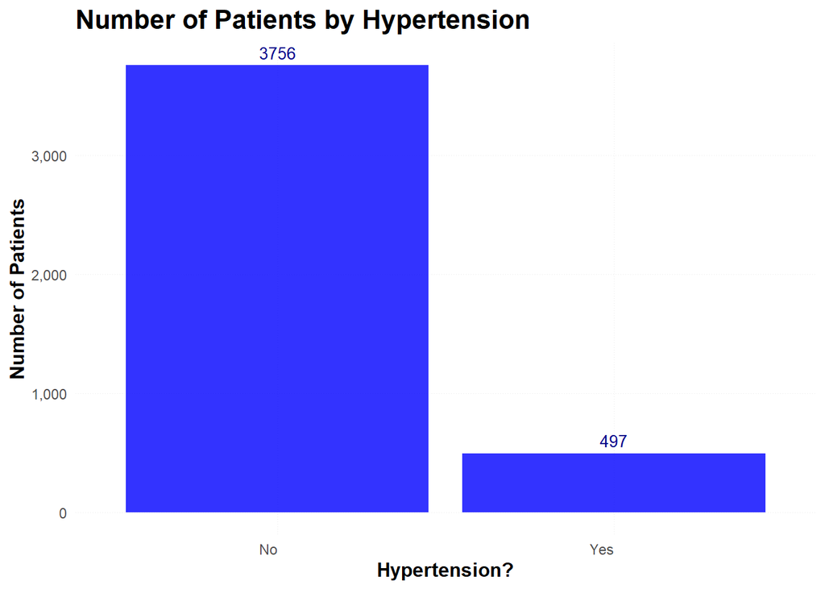

```r
ggplot(hypertension_counts, aes(x = hypertension_yn, y = patient_count)) +
  geom_col(fill = "blue", alpha = 0.8) +
  geom_text(aes(label = patient_count), vjust = -0.5, size = 3.5, color = "darkblue") +
  scale_y_continuous(labels = comma) +
  labs(title = "Number of Patients by Hypertension",
       x = "Hypertension?",
       y = "Number of Patients") +
  theme_minimal() +
  theme(
    plot.title = element_text(size = 16, face = "bold"),
    plot.subtitle = element_text(size = 12),
    axis.title.x = element_text(size = 12, face = "bold"),
    axis.title.y = element_text(size = 12, face = "bold"),
    axis.text.x = element_text(hjust = 1),
    panel.grid.major = element_line(size = 0.1, linetype = 'dotted'),
    panel.grid.minor = element_blank()
  )
```

```r
hypertension_counts_w_stroke <- stroke_data %>%
  group_by(hypertension_yn,stroke_yn) %>%
  summarise(patient_count = n()) %>%
  mutate(percentage = (patient_count / sum(patient_count)) * 100,
                 percentage = signif(percentage, 3)) %>%
  arrange(hypertension_yn)

hypertension_counts_w_stroke_table <- hypertension_counts_w_stroke %>% rename("Percentage (%)" = percentage) %>% rename("No.Patients" = patient_count) %>% rename("Hypertension?" = hypertension_yn) %>% rename("Stroke (Yes/No)" = stroke_yn)

flextable(hypertension_counts_w_stroke_table)
```

| Hypertension (Yes/No) | Stroke (Yes/No) | No.Patients | Percentage (%) |
| --- | --- | --- | --- |
| No | No | 3,575 | 95.20 |
| No | Yes | 181 | 4.82 |
| Yes | No | 431 | 86.70 |
| Yes | Yes | 66 | 13.30 |

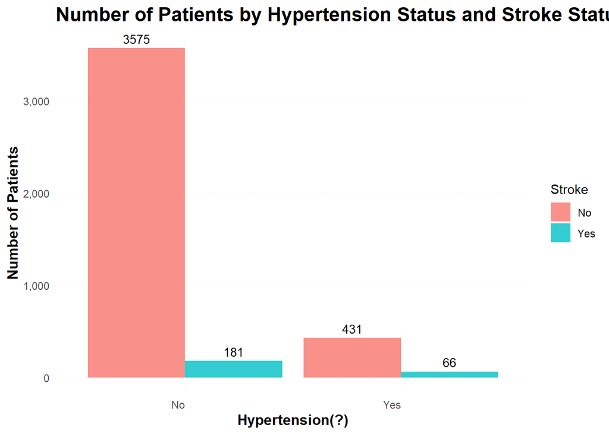

```r
ggplot(hypertension_counts_w_stroke, aes(x = hypertension_yn, y = patient_count, fill = stroke_yn)) +
  geom_col(position = "dodge", alpha = 0.8) +
  geom_text(aes(label = patient_count),
            position = position_dodge(width = 0.9),
            vjust = -0.5, size = 3.5) +
  scale_y_continuous(labels = scales::comma) +
  labs(title = "Number of Patients by Hypertension Status and Stroke Status",
       x = "Hypertension(?)",
       y = "Number of Patients",
       fill = "Stroke") +
  theme_minimal() +
  theme(
    plot.title = element_text(size = 16, face = "bold"),
    plot.subtitle = element_text(size = 12),
    axis.title.x = element_text(size = 12, face = "bold"),
    axis.title.y = element_text(size = 12, face = "bold"),
    axis.text.x = element_text(hjust = 1),
    panel.grid.major = element_line(size = 0.1, linetype = 'dotted'),
    panel.grid.minor = element_blank()
  )
```

The proportion of patients with hypertension who had a stroke (13.3%) is 2.75x higher than the proportion of patients without hypertension who had a stroke (4.82%).

### Work Type

```r
work_counts <- stroke_data %>%
  group_by(work_type) %>%
  summarise(patient_count = n()) %>%
  mutate(percentage = (patient_count / sum(patient_count)) * 100,
        percentage = signif(percentage, 3)) %>%
  arrange(work_type)

work_counts_table <- work_counts %>% rename("Percentage (%)" = percentage) %>% rename(
"No.Patients" = patient_count) %>% rename("Work Type" = work_type)

flextable(work_counts_table)
```

| Work Type | No.Patients | Percentage (%) |
| --- | --- | --- |
| Private | 2,790 | 65.600 |
| Govt_job | 651 | 15.300 |
| Self-employed | 807 | 19.000 |
|  | 5 | 0.118 |

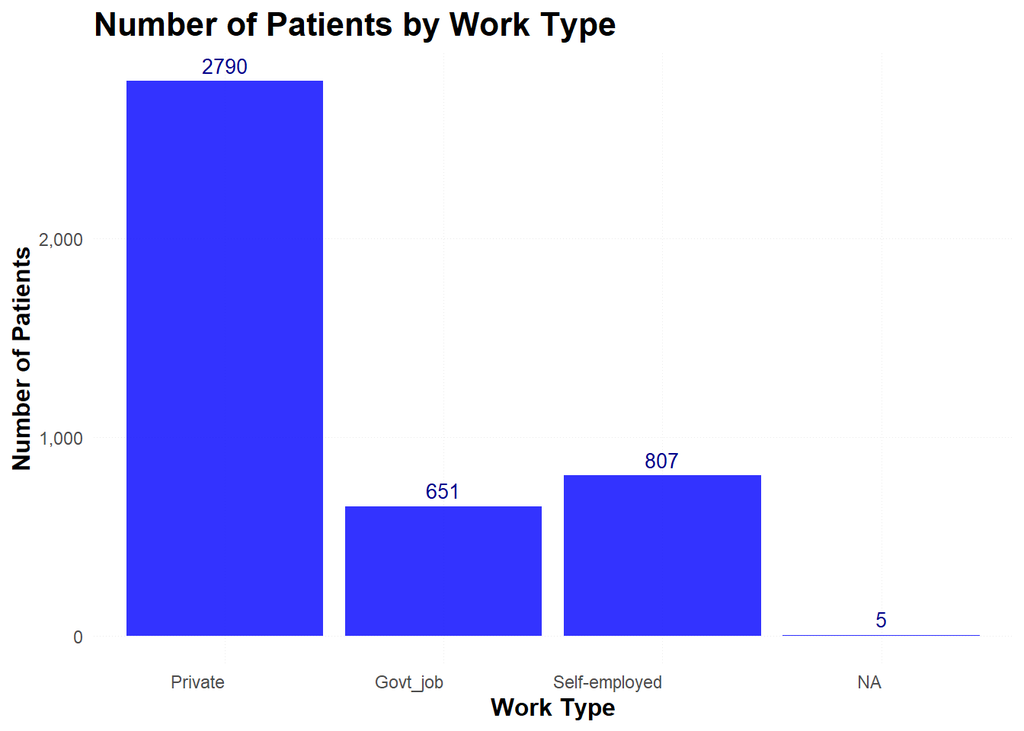

```r
ggplot(work_counts, aes(x = work_type, y = patient_count)) +
  geom_col(fill = "blue", alpha = 0.8) +
  geom_text(aes(label = patient_count), vjust = -0.5, size = 3.5, color = "darkblue") +
  scale_y_continuous(labels = comma) +
  labs(title = "Number of Patients by Work Type",
       x = "Work Type",
       y = "Number of Patients") +
  theme_minimal() +
  theme(
    plot.title = element_text(size = 16, face = "bold"),
    plot.subtitle = element_text(size = 12),
    axis.title.x = element_text(size = 12, face = "bold"),
    axis.title.y = element_text(size = 12, face = "bold"),
    axis.text.x = element_text(hjust = 1),
    panel.grid.major = element_line(size = 0.1, linetype = 'dotted'),
    panel.grid.minor = element_blank()
  )
```

### Chi-squared & Fisher’s Exact Tests

#### Chi-squared tests

```r
 stroke_data %>%
  summary_factorlist(dependent = "stroke_yn",
                     explanatory =
                       c("age_category", "bmi_category","ever_married","gender",
                         "heart_disease_yn", "hypertension_yn","residence_type",
                         "smoking_status","work_type"),
                     p = TRUE) %>%
     kable("html") %>%
  kable_styling(
    bootstrap_options = c("striped", "hover", "condensed"),
    full_width = TRUE,
    position = "center"
  )
```

| label | levels | No | Yes | p |
| --- | --- | --- | --- | --- |
| Age(years) | ≤60 | 2879 (71.9) | 70 (28.3) | <0.001 |
|  | >60 | 1127 (28.1) | 177 (71.7) |  |
| BMI | Normal weight | 883 (22.0) | 51 (20.6) | 0.610 |
|  | Underweight | 37 (0.9) | 1 (0.4) |  |
|  | Overweight | 1277 (31.9) | 87 (35.2) |  |
|  | Obese | 1809 (45.2) | 108 (43.7) |  |
| Ever Married? | No | 873 (21.8) | 27 (10.9) | <0.001 |
|  | Yes | 3133 (78.2) | 220 (89.1) |  |
| Gender | Female | 2437 (60.8) | 139 (56.3) | 0.175 |
|  | Male | 1569 (39.2) | 108 (43.7) |  |
| Heart Disease (Yes/No) | No | 3778 (94.3) | 200 (81.0) | <0.001 |
|  | Yes | 228 (5.7) | 47 (19.0) |  |
| Hypertension (Yes/No) | No | 3575 (89.2) | 181 (73.3) | <0.001 |
|  | Yes | 431 (10.8) | 66 (26.7) |  |
| Residence Type | Urban | 2035 (50.8) | 134 (54.3) | 0.323 |
|  | Rural | 1971 (49.2) | 113 (45.7) |  |
| Smoking Status | never smoked | 2116 (52.8) | 108 (43.7) | <0.001 |
|  | formerly smoked | 967 (24.1) | 91 (36.8) |  |
|  | smokes | 923 (23.0) | 48 (19.4) |  |
| Work Type | Private | 2641 (66.0) | 149 (60.3) | 0.010 |
|  | Govt_job | 618 (15.4) | 33 (13.4) |  |
|  | Self-employed | 742 (18.5) | 65 (26.3) |  |

#### Fisher’s exact tests

```r
 stroke_data %>%
  summary_factorlist(dependent = "stroke_yn",
                     explanatory =
                       c("age_category", "bmi_category","ever_married","gender",
                         "heart_disease_yn", "hypertension_yn","residence_type",
                         "smoking_status","work_type"),
                     p = TRUE,
                     p_cat = "fisher") %>%
     kable("html") %>%
  kable_styling(
    bootstrap_options = c("striped", "hover", "condensed"),
    full_width = TRUE,
    position = "center"
  )
```

| label | levels | No | Yes | p |
| --- | --- | --- | --- | --- |
| Age(years) | ≤60 | 2879 (71.9) | 70 (28.3) | <0.001 |
|  | >60 | 1127 (28.1) | 177 (71.7) |  |
| BMI | Normal weight | 883 (22.0) | 51 (20.6) | 0.696 |
|  | Underweight | 37 (0.9) | 1 (0.4) |  |
|  | Overweight | 1277 (31.9) | 87 (35.2) |  |
|  | Obese | 1809 (45.2) | 108 (43.7) |  |
| Ever Married? | No | 873 (21.8) | 27 (10.9) | <0.001 |
|  | Yes | 3133 (78.2) | 220 (89.1) |  |
| Gender | Female | 2437 (60.8) | 139 (56.3) | 0.159 |
|  | Male | 1569 (39.2) | 108 (43.7) |  |
| Heart Disease (Yes/No) | No | 3778 (94.3) | 200 (81.0) | <0.001 |
|  | Yes | 228 (5.7) | 47 (19.0) |  |
| Hypertension (Yes/No) | No | 3575 (89.2) | 181 (73.3) | <0.001 |
|  | Yes | 431 (10.8) | 66 (26.7) |  |
| Residence Type | Urban | 2035 (50.8) | 134 (54.3) | 0.295 |
|  | Rural | 1971 (49.2) | 113 (45.7) |  |
| Smoking Status | never smoked | 2116 (52.8) | 108 (43.7) | <0.001 |
|  | formerly smoked | 967 (24.1) | 91 (36.8) |  |
|  | smokes | 923 (23.0) | 48 (19.4) |  |
| Work Type | Private | 2641 (66.0) | 149 (60.3) | 0.013 |
|  | Govt_job | 618 (15.4) | 33 (13.4) |  |
|  | Self-employed | 742 (18.5) | 65 (26.3) |  |

### Facetted Visualisations

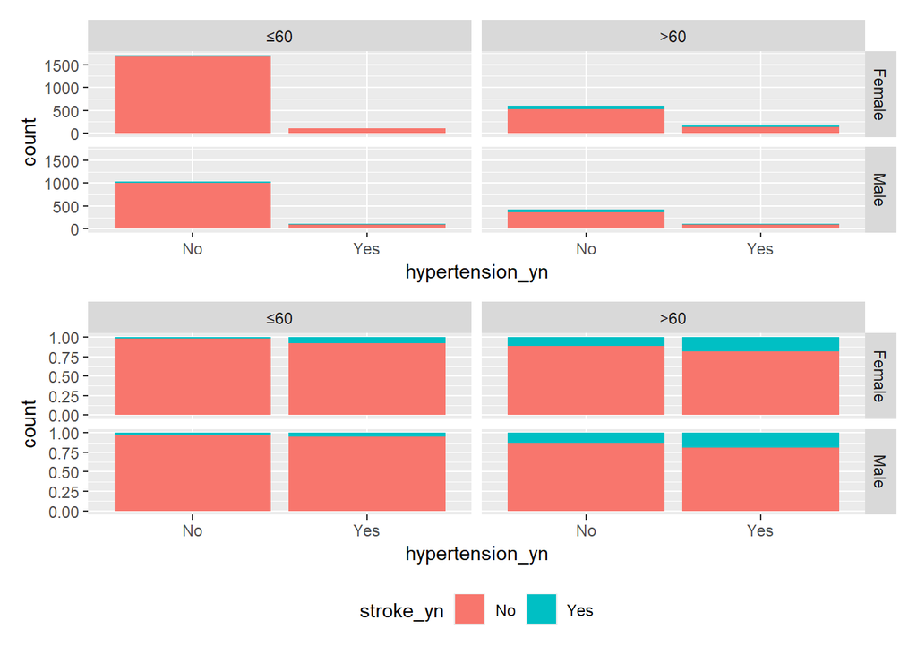

```r
p1 <- stroke_data %>%
  ggplot(aes(x = hypertension_yn, fill=stroke_yn)) +
  geom_bar(position = position_stack(reverse = TRUE)) +
  facet_grid(gender ~ age_category) +
  theme(legend.position = "none")

p2 <- stroke_data %>%
  ggplot(aes(x = hypertension_yn, fill=stroke_yn)) +
  geom_bar(position = position_fill(reverse = TRUE)) +
  facet_grid(gender ~ age_category)+
  theme(legend.position = "bottom")

p1 / p2
```

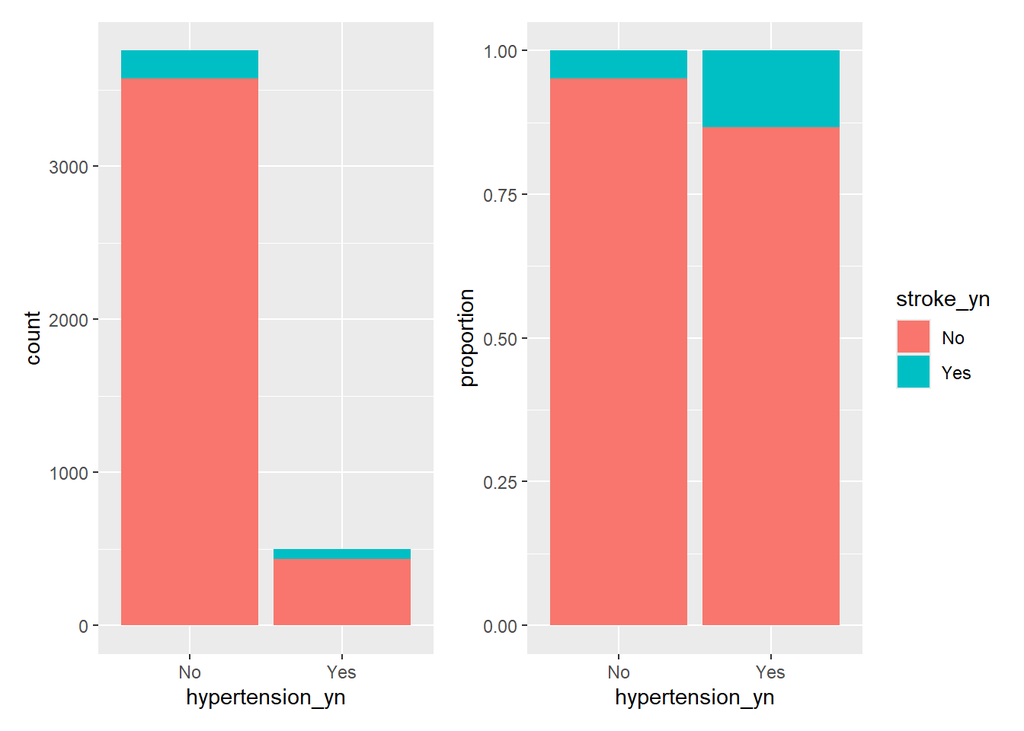

```r
p1 <- stroke_data %>%
  ggplot(aes(x = hypertension_yn, fill = stroke_yn)) +
  geom_bar(position = position_stack(reverse = TRUE)) +
  theme(legend.position = "none")

p2 <- stroke_data %>%
  ggplot(aes(x = hypertension_yn, fill = stroke_yn)) +
  geom_bar(position = position_fill(reverse = TRUE)) +
  ylab("proportion")

p1 + p2
```

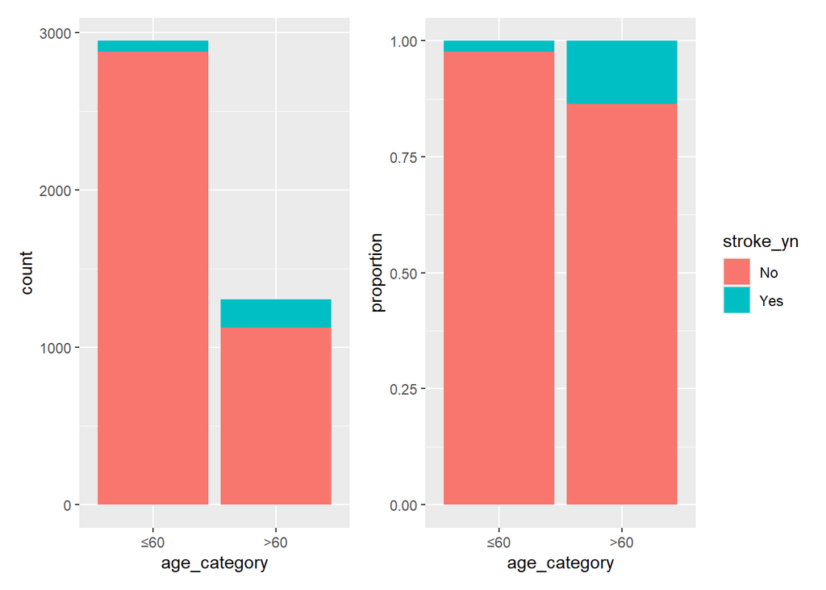

```r
p1 <- stroke_data %>%
  ggplot(aes(x = age_category, fill = stroke_yn)) +
  geom_bar(position = position_stack(reverse = TRUE)) +
  theme(legend.position = "none")

p2 <- stroke_data %>%
  ggplot(aes(x = age_category, fill = stroke_yn)) +
  geom_bar(position = position_fill(reverse = TRUE)) +
  ylab("proportion")

p1 + p2
```

## Survival Analysis

[output not shown]

### Overall Survival

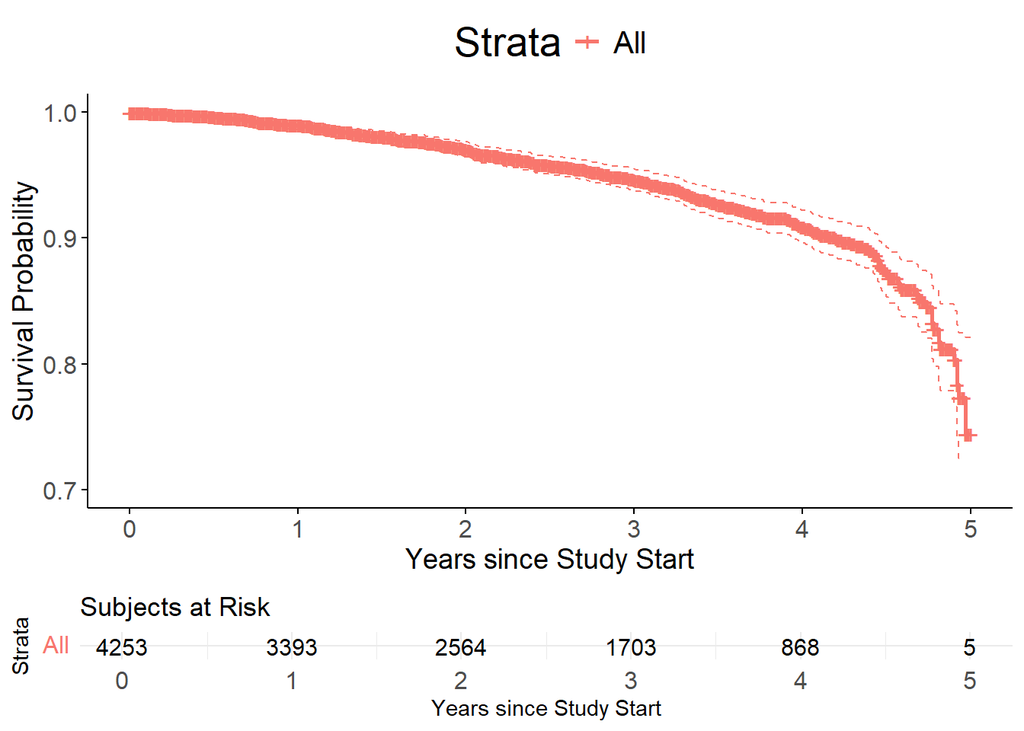

```r
ggsurvplot(
  fit_stroke,
  xlim = c(0, 5),
  ylim = c(0.7, 1),
  break.time.by = 1,
  xlab = "Years since Study Start",
  ylab = "Survival Probability",
  pval = TRUE,
  ggtheme = theme_minimal() + theme(
    panel.grid.major = element_blank(), # Remove major grid lines
    panel.grid.minor = element_blank(), # Remove minor grid lines
    panel.background = element_blank(), # Remove panel background
    plot.background = element_blank(),  # Remove plot background
    axis.line = element_line(color = "black"), # Keep axis lines
    axis.title = element_text(size = 14), # Increase axis title size
    axis.text = element_text(size = 12),  # Increase axis text size
    legend.text = element_text(size = 15), # Increase legend text size
    legend.title = element_text(size = 20), # Increase legend title size
    plot.title = element_text(size = 20), # Increase plot title size
    plot.subtitle = element_text(size = 13), # Increase plot subtitle size
    legend.key.size = unit(1, "lines")      # Adjust legend key size
  ),
  risk.table = TRUE,
  risk.table.y.text.col = TRUE,
  risk.table.height = 0.2,                 # Slightly increase height of risk table
  risk.table.y.text = TRUE,
  conf.int = TRUE,
  cumcensor = FALSE,
  conf.int.style = "step",
  risk.table.fontsize = 4,                 # Reduce risk table font size
  risk.table.title = "Subjects at Risk",   # Set risk table title
  tables.theme = theme_minimal() + theme(
    axis.text.x = element_text(size = 12), # Adjust x-axis text in risk table
    axis.text.y = element_text(size = 12)  # Adjust y-axis text in risk table
  )
)
```

```r
summary(survfit(Surv(follow_up_years, status) ~ 1, data = stroke_data), times = 3)
```

```
## Call: survfit(formula = Surv(follow_up_years, status) ~ 1, data = stroke_data)
##
##  time n.risk n.event survival std.err lower 95% CI upper 95% CI
##     3   1703     151    0.946 0.00438        0.938        0.955
```

```r
survfit(Surv(follow_up_years, status) ~ 1, data = stroke_data) %>%
  tbl_survfit(
    times = 3,
    label_header = "**3-year survival (95% CI)**"
  )
```

| **Characteristic** | **3-year survival (95% CI)** |
| --- | --- |
| Overall | 95% (94%, 95%) |

```r
stroke_data %>%
  filter(status == 1) %>%
  summarize(median_surv = median(follow_up_years))
```

```
## # A tibble: 1 × 1
##   median_surv
##         <dbl>
## 1        2.41
```

### Smoking Status

```
## Call: survfit(formula = Surv(follow_up_years, status) ~ smoking_status,
##     data = stroke_data)
##
##                                   n events median 0.95LCL 0.95UCL
## smoking_status=never smoked    2224    108     NA      NA      NA
## smoking_status=formerly smoked 1058     91     NA      NA      NA
## smoking_status=smokes           971     48     NA    4.97      NA
```

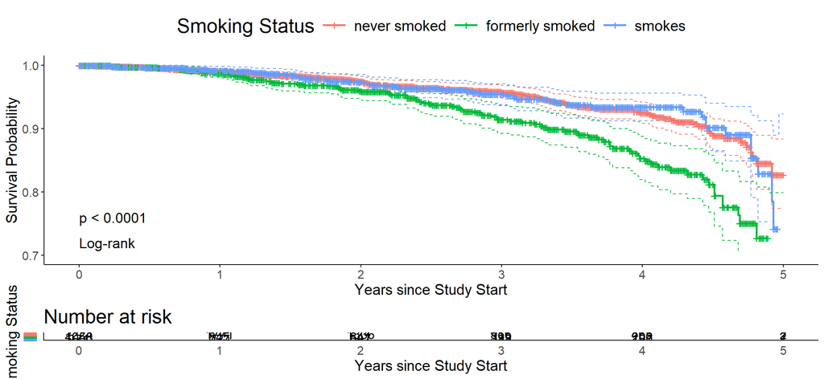

```r
legend_labels <- c("never smoked", "formerly smoked", "smokes")

ggsurvplot(
  fit_smoking,
  xlim = c(0, 5),
  ylim = c(0.7, 1),
  break.time.by = 1,
  xlab = "Years since Study Start",
  ylab = "Survival Probability",
  pval = TRUE,
  ggtheme = theme_minimal() + theme(
                  panel.grid.major = element_blank(), # Remove major grid lines
                  panel.grid.minor = element_blank(), # Remove minor grid lines
                  panel.background = element_blank(), # Remove panel background
                  plot.background = element_blank(),  # Remove plot background
                  axis.line = element_line(color = "black"), # Keep axis lines if desired
                  axis.title = element_text(size = 15), # Increase axis title size
                  axis.text = element_text(size = 12),  # Increase axis text size
                  legend.text = element_text(size = 15), # Increase legend text size
                  legend.title = element_text(size = 20), # Increase legend title size
                  plot.title = element_text(size = 20), # Increase plot title size
                  plot.subtitle = element_text(size = 15), # Increase plot subtitle size
                  legend.key.size = unit(2, "lines") # Increase legend key size
                ),
           risk.table = TRUE,
           risk.table.y.text.col = TRUE,
           risk.table.height = 0.2,
           risk.table.y.text = FALSE,
           conf.int = TRUE, cumcensor = FALSE, conf.int.style = "step",pval.coord = c(0, 0.76), pval.method = TRUE, pval.method.coord = c(0, 0.72),
           legend.labs = legend_labels,
           legend.title = "Smoking Status",pval.size = 5, pval.method.size = 5 # Set legend title
)
```

Quantifying the effect size for multiple variables using Cox Regression -

Some key assumptions of the model:

- non-informative censoring
- proportional hazards

```r
coxph(Surv(follow_up_years, status) ~ smoking_status, data = stroke_data) %>%
  tbl_regression(exp = TRUE)
```

| **Characteristic** | **HR**<sup>1</sup> | **95% CI**<sup>1</sup> | **p-value** |
| --- | --- | --- | --- |
| Smoking Status |  |  |  |
| never smoked | — | — |  |
| formerly smoked | 1.88 | 1.42, 2.48 | <0.001 |
| smokes | 1.03 | 0.73, 1.45 | 0.9 |

<sup>1</sup> HR = Hazard Ratio, CI = Confidence Interval

### Age

```
## Call: survfit(formula = Surv(follow_up_years, status) ~ age_category,
##     data = stroke_data)
##
##                     n events median 0.95LCL 0.95UCL
## age_category=≤60 2949     70     NA      NA      NA
## age_category=>60 1304    177   4.97    4.92      NA
```

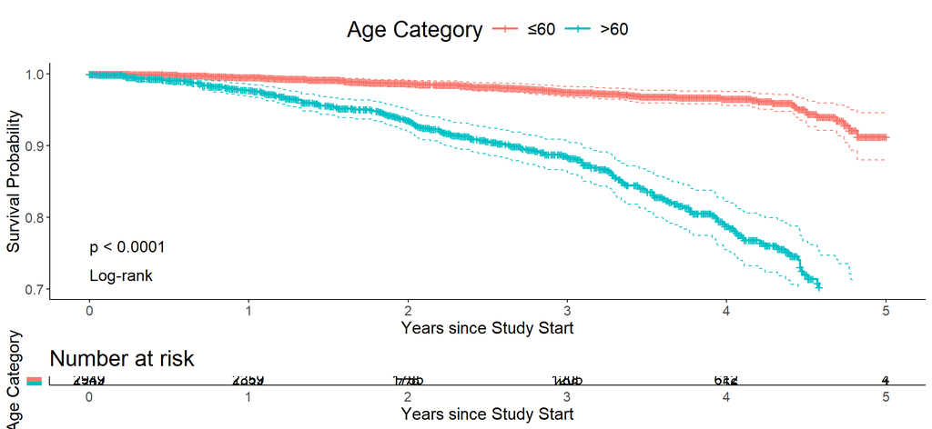

```r
legend_labels <- c("≤60", ">60")

ggsurvplot(
  fit_age,
  xlim = c(0, 5),
  ylim = c(0.7, 1),
  break.time.by = 1,
  xlab = "Years since Study Start",
  ylab = "Survival Probability",
  pval = TRUE,
  ggtheme = theme_minimal() + theme(
                  panel.grid.major = element_blank(), # Remove major grid lines
                  panel.grid.minor = element_blank(), # Remove minor grid lines
                  panel.background = element_blank(), # Remove panel background
                  plot.background = element_blank(),  # Remove plot background
                  axis.line = element_line(color = "black"), # Keep axis lines if desired
                  axis.title = element_text(size = 15), # Increase axis title size
                  axis.text = element_text(size = 12),  # Increase axis text size
                  legend.text = element_text(size = 15), # Increase legend text size
                  legend.title = element_text(size = 20), # Increase legend title size
                  plot.title = element_text(size = 20), # Increase plot title size
                  plot.subtitle = element_text(size = 15), # Increase plot subtitle size
                  legend.key.size = unit(2, "lines") # Increase legend key size
                ),
           risk.table = TRUE,
           risk.table.y.text.col = TRUE,
           risk.table.height = 0.2,
           risk.table.y.text = FALSE,
           conf.int = TRUE, cumcensor = FALSE, conf.int.style = "step",pval.coord = c(0, 0.76), pval.method = TRUE, pval.method.coord = c(0, 0.72),
           legend.labs = legend_labels,
           legend.title = "Age Category",pval.size = 5, pval.method.size = 5 # Set legend title
)
```

```r
coxph(Surv(follow_up_years, status) ~ age_category, data = stroke_data) %>%
  tbl_regression(exp = TRUE)
```

| **Characteristic** | **HR**<sup>1</sup> | **95% CI**<sup>1</sup> | **p-value** |
| --- | --- | --- | --- |
| Age(years) |  |  |  |
| ≤60 | — | — |  |
| >60 | 5.81 | 4.40, 7.66 | <0.001 |

<sup>1</sup> HR = Hazard Ratio, CI = Confidence Interval

```r
# ci_fit <- cuminc(stroke_data$follow_up_years , stroke_data$status)
#
# ciplot <- ci_fit %>% list_modify("Tests" = NULL) %>%
#   map_df(`[`, c("time", "est", "var"), .id = "id") %>%
#    mutate(Stroke = recode(
#     id,
#     "1 1" = "Stroke"))
#
#
# ggplot(ciplot, aes(x = time, y = est, color = Stroke)) +
#   geom_step(lwd = 1.2) +
#   scale_y_continuous(limits = c(0, 0.4), labels = scales::percent_format(accuracy = 1)) +  # Format y-axis as percentages
#   scale_x_continuous(breaks = seq(0, 5, 1), limits = c(0, 5)) +  # Setting limits here
#   theme_minimal() +  # Use theme_minimal for a simple background
#   theme(
#     plot.title = element_text(size = 25), # Increase plot title size
#     legend.title = element_blank(),
#     legend.position = "bottom",
#     axis.title = element_text(size = 20), # Increase axis title size
#     axis.text = element_text(size = 17),  # Increase axis text size
#     legend.text = element_text(size = 20), # Increase legend text size
#     panel.grid.major = element_blank(),  # Remove major grid lines
#     panel.grid.minor = element_blank(),  # Remove minor grid lines
#     panel.background = element_rect(fill = "white", color = NA),  # Ensure background is white and remove panel border
#     plot.background = element_rect(fill = "white", color = NA),  # Ensure plot area is white and remove plot border
#     axis.line = element_line(color = "black"),  # Keep axis lines
#     axis.line.y.right = element_blank(),  # Remove right side axis line
#     axis.line.x.top = element_blank()  # Remove top side axis line
#   ) +
#   labs(
#     x = "Days",
#     y = "Cumulative Strokes",
#     title = "All Patients"
#   )
```

```r
# ci_smoking <- cuminc(stroke_data$follow_up_years , stroke_data$status, group = stroke_data$smoking_status)
#
# ciplot <- ci_smoking %>% list_modify("Tests" = NULL) %>%
#   map_df(`[`, c("time", "est", "var"), .id = "id") %>%
#    mutate(id = recode(
#     id,
#     "never smoked 1" = "Never Smoked Strokes",
#     "formerly smoked 1" = "Formerly Smoked Strokes",
#     "smokes 1" = "Smoked Strokes")) %>%
#   separate(id, c("smoking_status","Event"),":")
#
#
# ggplot(ciplot, aes(x = time, y = est, color = smoking_status)) +
#   geom_step(lwd = 1.2) +
#   scale_y_continuous(limits = c(0, 0.4), labels = scales::percent_format(accuracy = 1)) +  # Format y-axis as percentages
#   scale_x_continuous(breaks = seq(0, 5, 1), limits = c(0, 5)) +  # Setting limits here
#   theme_minimal() +  # Use theme_minimal for a simple background
#   theme(
#     plot.title = element_text(size = 20), # Increase plot title size
#     legend.title = element_blank(),
#     legend.position = "bottom",
#     axis.title = element_text(size = 10), # Increase axis title size
#     axis.text = element_text(size = 8),  # Increase axis text size
#     legend.text = element_text(size = 10), # Increase legend text size
#     panel.grid.major = element_blank(),  # Remove major grid lines
#     panel.grid.minor = element_blank(),  # Remove minor grid lines
#     panel.background = element_rect(fill = "white", color = NA),  # Ensure background is white and remove panel border
#     plot.background = element_rect(fill = "white", color = NA),  # Ensure plot area is white and remove plot border
#     axis.line = element_line(color = "black"),  # Keep axis lines
#     axis.line.y.right = element_blank(),  # Remove right side axis line
#     axis.line.x.top = element_blank()  # Remove top side axis line
#   ) +
#   labs(
#     x = "Days",
#     y = "Cumulative strokes",
#     title = "Stratified by Smoking Status"
#   ) +
#   annotate("text", x = 0, y = 0.26, hjust = 0,
#            label = paste0(
#              "Log-rank p-value = ",
#              ifelse(ci_smoking$Tests[1,2] < .001,
#                     "<.001",
#                     round(ci_smoking$Tests[1,2], 3))),
#            size = 5)
```